# Cars4U Linear Regression Project

#### Background & Context

There is a huge demand for used cars in the Indian Market today. As sales of new cars have slowed down in the recent past, the pre-owned car market has continued to grow over the past years and is larger than the new car market now. Cars4U is a budding tech start-up that aims to find footholes in this market.

In 2018-19, while new car sales were recorded at 3.6 million units, around 4 million second-hand cars were bought and sold. There is a slowdown in new car sales and that could mean that the demand is shifting towards the pre-owned market. In fact, some car sellers replace their old cars with pre-owned cars instead of buying new ones. Unlike new cars, where price and supply are fairly deterministic and managed by OEMs (Original Equipment Manufacturer / except for dealership level discounts which come into play only in the last stage of the customer journey), used cars are very different beasts with huge uncertainty in both pricing and supply. Keeping this in mind, the pricing scheme of these used cars becomes important in order to grow in the market.

As a senior data scientist at Cars4U, you have to come up with a pricing model that can effectively predict the price of used cars and can help the business in devising profitable strategies using differential pricing. For example, if the business knows the market price, it will never sell anything below it.

#### Data Dictionary of Dataset

S.No. : Serial Number

Name : Name of the car which includes Brand name and Model name

Location : The location in which the car is being sold or is available for purchase Cities

Year : Manufacturing year of the car

Kilometers_driven : The total kilometers driven in the car by the previous owner(s) in KM.

Fuel_Type : The type of fuel used by the car. (Petrol, Diesel, Electric, CNG, LPG)

Transmission : The type of transmission used by the car. (Automatic / Manual)

Owner : Type of ownership

Mileage : The standard mileage offered by the car company in kmpl or km/kg

Engine : The displacement volume of the engine in CC.

Power : The maximum power of the engine in bhp.

Seats : The number of seats in the car.

New_Price : The price of a new car of the same model in INR Lakhs.(1 Lakh = 100, 000)

Price : The price of the used car in INR Lakhs (1 Lakh = 100, 000)

#### Problem Objective

1. Explore and visualize the dataset.
2. Peform Univariate and Bivariate analysis of features. Bring out the insights in the data.
3. Preprocess the data and find out duplicates, missing values and treatment, outliers and treatment, bad data.
4. Build a linear regression model to predict the prices of used cars.
5. Performance evaluation of model - Generate RMSE, MAE, Adjusted R-square.
6. Generate a set of insights and recommendations that will help the business.

#### Questions to be Answered

1. What are the features influencing the pricing of the car?
2. Does Brand or Model of the car has any impact on the pricing?
3. Does the location of the car being sold has any impact on pricing?
4. Does the age of the car(i.e year) being sold has any effect on pricing?
5. Does Kilometers Driven in car impacts pricing? Are Kilometers Driven and Pricing are inversely proportional?
6. Does Fuel type,Transmission has any impact on car pricing?
7. Any relation between pricing of car and Owner type? Are they inversely proportional? If the car is being owned by more number of users decreases car pricing?
8. Any relation between Engine, Power & Seats on pricing of car?
9. How does standard mileage of car affect the pricing?

## Import necessary libraries

```python
import numpy as np
import pandas as pd
import seaborn as sns
import random
import matplotlib.pyplot as plt
sns.set(color_codes=True)
%matplotlib inline
import warnings
warnings.filterwarnings('ignore')
# Removes the limit for the number of displayed columns
pd.set_option("display.max_columns", None)
# Sets the limit for the number of displayed rows
pd.set_option("display.max_rows", 200)
# To build linear model for prediction
from sklearn.linear_model import LinearRegression
# To check model performance
from sklearn.metrics import mean_squared_error, r2_score, mean_absolute_error
```

#### Loading and exploring the data

```python
#Read the input file
car_data=pd.read_csv('C:/Users/srikant/Downloads/used_cars_data.csv')

# Retaining the actual file and taking a copy of input as working file
carsdf = car_data.copy()
```

##### Lets check the shape and sample records in the dataset

```python
np.random.seed(1)  # To get the same random results every time
display(carsdf.sample(8))  # Print sample records
print(f'\nThere are {carsdf.shape[0]} rows and {carsdf.shape[1]} columns.\n')  # Shape of the input file
```

|  | S.No. | Name | Location | Year | Kilometers_Driven | Fuel_Type | Transmission | Owner_Type | Mileage | Engine | Power | Seats | New_Price | Price |
| --- | --- | --- | --- | --- | --- | --- | --- | --- | --- | --- | --- | --- | --- | --- |
| 2397 | 2397 | Ford EcoSport 1.5 Petrol Trend | Kolkata | 2016 | 21460 | Petrol | Manual | First | 17.0 kmpl | 1497 CC | 121.36 bhp | 5.0 | 9.47 | 6.00 |
| 3777 | 3777 | Maruti Wagon R VXI 1.2 | Kochi | 2015 | 49818 | Petrol | Manual | First | 21.5 kmpl | 1197 CC | 81.80 bhp | 5.0 | 5.44 | 4.11 |
| 4425 | 4425 | Ford Endeavour 4x2 XLT | Hyderabad | 2007 | 130000 | Diesel | Manual | First | 13.1 kmpl | 2499 CC | 141 bhp | 7.0 | 35.29 | 6.00 |
| 3661 | 3661 | Mercedes-Benz E-Class E250 CDI Avantgrade | Coimbatore | 2016 | 39753 | Diesel | Automatic | First | 13.0 kmpl | 2143 CC | 201.1 bhp | 5.0 | 86.97 | 35.28 |
| 4514 | 4514 | Hyundai Xcent 1.2 Kappa AT SX Option | Kochi | 2016 | 45560 | Petrol | Automatic | First | 16.9 kmpl | 1197 CC | 82 bhp | 5.0 | 8.23 | 6.34 |
| 599 | 599 | Toyota Innova Crysta 2.8 ZX AT | Coimbatore | 2019 | 40674 | Diesel | Automatic | First | 11.36 kmpl | 2755 CC | 171.5 bhp | 7.0 | 28.05 | 24.82 |
| 186 | 186 | Mercedes-Benz E-Class E250 CDI Avantgrade | Bangalore | 2014 | 37382 | Diesel | Automatic | First | 13.0 kmpl | 2143 CC | 201.1 bhp | 5.0 | 86.97 | 32.00 |
| 305 | 305 | Audi A6 2011-2015 2.0 TDI Premium Plus | Kochi | 2014 | 61726 | Diesel | Automatic | First | 17.68 kmpl | 1968 CC | 174.33 bhp | 5.0 | 67.10 | 20.77 |

```
There are 7253 rows and 14 columns.
```

The dataset has 7253 rows and 14 columns.As you can notice, The "S.No" column is not of any interest. Let's drop the column.

```python
#dropping S.No column from dataset
carsdf.drop(['S.No.'],axis=1,inplace=True)
```

##### Let's check the datatypes and size of the file

```python
carsdf.info()
```

```
<class 'pandas.core.frame.DataFrame'>
RangeIndex: 7253 entries, 0 to 7252
Data columns (total 13 columns):
 #   Column             Non-Null Count  Dtype
---  ------             --------------  -----
 0   Name               7253 non-null   object
 1   Location           7253 non-null   object
 2   Year               7253 non-null   int64
 3   Kilometers_Driven  7253 non-null   int64
 4   Fuel_Type          7253 non-null   object
 5   Transmission       7253 non-null   object
 6   Owner_Type         7253 non-null   object
 7   Mileage            7251 non-null   object
 8   Engine             7207 non-null   object
 9   Power              7078 non-null   object
 10  Seats              7200 non-null   float64
 11  New_Price          7253 non-null   float64
 12  Price              6019 non-null   float64
dtypes: float64(3), int64(2), object(8)
memory usage: 736.8+ KB
```

```python
#Summary statistics
carsdf.describe(include='all').T
```

|  | count | unique | top | freq | mean | std | min | 25% | 50% | 75% | max |
| --- | --- | --- | --- | --- | --- | --- | --- | --- | --- | --- | --- |
| Name | 7253 | 2041 | Mahindra XUV500 W8 2WD | 55 | NaN | NaN | NaN | NaN | NaN | NaN | NaN |
| Location | 7253 | 11 | Mumbai | 949 | NaN | NaN | NaN | NaN | NaN | NaN | NaN |
| Year | 7253.0 | NaN | NaN | NaN | 2013.365366 | 3.254421 | 1996.0 | 2011.0 | 2014.0 | 2016.0 | 2019.0 |
| Kilometers_Driven | 7253.0 | NaN | NaN | NaN | 58699.063146 | 84427.720583 | 171.0 | 34000.0 | 53416.0 | 73000.0 | 6500000.0 |
| Fuel_Type | 7253 | 5 | Diesel | 3852 | NaN | NaN | NaN | NaN | NaN | NaN | NaN |
| Transmission | 7253 | 2 | Manual | 5204 | NaN | NaN | NaN | NaN | NaN | NaN | NaN |
| Owner_Type | 7253 | 4 | First | 5952 | NaN | NaN | NaN | NaN | NaN | NaN | NaN |
| Mileage | 7251 | 450 | 17.0 kmpl | 207 | NaN | NaN | NaN | NaN | NaN | NaN | NaN |
| Engine | 7207 | 150 | 1197 CC | 732 | NaN | NaN | NaN | NaN | NaN | NaN | NaN |
| Power | 7078 | 385 | 74 bhp | 280 | NaN | NaN | NaN | NaN | NaN | NaN | NaN |
| Seats | 7200.0 | NaN | NaN | NaN | 5.279722 | 0.81166 | 0.0 | 5.0 | 5.0 | 5.0 | 10.0 |
| New_Price | 7253.0 | NaN | NaN | NaN | 21.307322 | 24.256314 | 3.91 | 7.88 | 11.3 | 21.69 | 375.0 |
| Price | 6019.0 | NaN | NaN | NaN | 9.479468 | 11.187917 | 0.44 | 3.5 | 5.64 | 9.95 | 160.0 |

##### Lets further explore the dataset statistics.

1. How many numerical & Categorical columns we have?
2. Shape (remember we have dropped S.No. already)
3. Number of variables
4. Missing cells
5. Duplicate rows

```python
#setting max column width so that column names doesnt get truncated
pd.set_option('max_colwidth', 100)

#creating empty dataframe
df1=pd.DataFrame()

#Find out numerical, categorical variables, shape of dataset, missing values and its %, dups in dataset and its %
#convert the output of the different stats into List
#fill in the dataframe and then display

#checking number of Numerical Variables using len() & select_dtypes
df1["Number of Numerical variables"] = [len(carsdf.select_dtypes('number').columns)]

#Numerical Variables in dataset
df1["Numerical Columns"] = [carsdf.select_dtypes('number').columns.tolist()]

#number of Object(Categorical) Variables using len() & select_dtypes
df1["Number of Object variables"] = [len(carsdf.select_dtypes('object').columns)]

#Categorical Variables in dataset
df1["Object Columns"] = [carsdf.select_dtypes('object').columns.tolist()]

#Number of columns in dataset from shape
df1["Total Number of variables"] = [carsdf.shape[1]]

#Number of rows in dataset from shape
df1["Total Number of rows"] = [carsdf.shape[0]]
#Calculating number of missing cells/null values in file
df1["Missing cells"] = [carsdf.isnull().sum().sum()]

#Converting the missing cells numbers into %
df1["Missing cells(%)"] = [(carsdf.isnull().sum().sum())*100/(carsdf.shape[0] * carsdf.shape[1])]

#Calculating duplicate rows in file
df1["Duplicate rows"] = [carsdf.duplicated().sum()]

#Converting the duplicate cells numbers into %
df1["Duplicate rows(%)"] = [(carsdf.duplicated().sum()*100)/carsdf.shape[0]]

#Renaming the column name
display(df1.T.rename(columns={0:'Dataset Statistics'}))
```

|  | Dataset Statistics |
| --- | --- |
| Number of Numerical variables | 5 |
| Numerical Columns | [Year, Kilometers_Driven, Seats, New_Price, Price] |
| Number of Object variables | 8 |
| Object Columns | [Name, Location, Fuel_Type, Transmission, Owner_Type, Mileage, Engine, Power] |
| Total Number of variables | 13 |
| Total Number of rows | 7253 |
| Missing cells | 1510 |
| Missing cells(%) | 1.601459 |
| Duplicate rows | 1 |
| Duplicate rows(%) | 0.013787 |

##### Lets check the duplicate record and drop it

```python
#carsdf[carsdf.duplicated()]
carsdf.duplicated().sum()    #after dropping S.No.
```

```
1
```

```python
print('Shape of dataset before dropping dups:', carsdf.shape)
print('Dropping duplicate and retaining last occurrence')
carsdf.drop_duplicates(keep='last',inplace=True)
print('Dropping complete')
print('Confirming if duplicate still exist in file')
print('Number of duplicates in dataset:',carsdf.duplicated().sum())
print('Shape of dataset after dropping dups:', carsdf.shape)
```

```
Shape of dataset before dropping dups: (7253, 13)
Dropping duplicate and retaining last occurrence
Dropping complete
Confirming if duplicate still exist in file
Number of duplicates in dataset: 0
Shape of dataset after dropping dups: (7252, 13)
```

As you see above, we have dropped one duplicate row in file and no dups exists in file

##### Let's check for Unique values in the data.

```python
carsdf.nunique()
```

```
Name                 2041
Location               11
Year                   23
Kilometers_Driven    3660
Fuel_Type               5
Transmission            2
Owner_Type              4
Mileage               450
Engine                150
Power                 385
Seats                   9
New_Price             643
Price                1373
dtype: int64
```

##### Let's check the values in columns

```python
cols=['Location','Year','Fuel_Type','Transmission','Owner_Type','Seats']
for i in cols:
    print('Unique values and count of column',i,'are:')
    display(pd.DataFrame(carsdf[i].value_counts(dropna=False,ascending=True)))
```

```
Unique values and count of column Location are:
```

|  | Location |
| --- | --- |
| Ahmedabad | 275 |
| Bangalore | 440 |
| Jaipur | 499 |
| Chennai | 591 |
| Kolkata | 654 |
| Delhi | 660 |
| Pune | 765 |
| Coimbatore | 772 |
| Kochi | 772 |
| Hyderabad | 876 |
| Mumbai | 948 |

```
Unique values and count of column Year are:
```

|  | Year |
| --- | --- |
| 1996 | 1 |
| 1999 | 2 |
| 1998 | 4 |
| 2000 | 5 |
| 2001 | 8 |
| 2002 | 18 |
| 2003 | 20 |
| 2004 | 35 |
| 2005 | 68 |
| 2006 | 89 |
| 2019 | 119 |
| 2007 | 148 |
| 2008 | 207 |
| 2009 | 252 |
| 2018 | 361 |
| 2010 | 406 |
| 2011 | 579 |
| 2012 | 690 |
| 2017 | 709 |
| 2013 | 791 |
| 2016 | 886 |
| 2014 | 925 |
| 2015 | 929 |

```
Unique values and count of column Fuel_Type are:
```

|  | Fuel_Type |
| --- | --- |
| Electric | 2 |
| LPG | 12 |
| CNG | 62 |
| Petrol | 3324 |
| Diesel | 3852 |

```
Unique values and count of column Transmission are:
```

|  | Transmission |
| --- | --- |
| Automatic | 2049 |
| Manual | 5203 |

```
Unique values and count of column Owner_Type are:
```

|  | Owner_Type |
| --- | --- |
| Fourth & Above | 12 |
| Third | 137 |
| Second | 1152 |
| First | 5951 |

```
Unique values and count of column Seats are:
```

|  | Seats |
| --- | --- |
| 0.0 | 1 |
| 9.0 | 3 |
| 10.0 | 8 |
| 2.0 | 18 |
| 6.0 | 38 |
| NaN | 53 |
| 4.0 | 119 |
| 8.0 | 170 |
| 7.0 | 796 |
| 5.0 | 6046 |

As you can see above, all the variables have good values. However, notice Seats variable having NaN and 0.0 values. Impute values later

```python
print('Missing values:\n')
print(carsdf.isnull().sum())
print('\nMissing values(%):\n')
print(carsdf.isnull().sum() * 100 / len(carsdf))
```

```
Missing values:

Name                    0
Location                0
Year                    0
Kilometers_Driven       0
Fuel_Type               0
Transmission            0
Owner_Type              0
Mileage                 2
Engine                 46
Power                 175
Seats                  53
New_Price               0
Price                1233
dtype: int64

Missing values(%):

Name                  0.000000
Location              0.000000
Year                  0.000000
Kilometers_Driven     0.000000
Fuel_Type             0.000000
Transmission          0.000000
Owner_Type            0.000000
Mileage               0.027579
Engine                0.634308
Power                 2.413127
Seats                 0.730833
New_Price             0.000000
Price                17.002206
dtype: float64
```

Mileage, Engine, Power, Seats has very minimal. We should be able to impute the values.

# Data Preprocessing

Let's fix bad data and missing data in all columns

#### Seat variable

Seat = 0 and NaNs

```python
print('Records with Seats 0')
carsdf[carsdf['Seats']==0.0]
```

```
Records with Seats 0
```

|  | Name | Location | Year | Kilometers_Driven | Fuel_Type | Transmission | Owner_Type | Mileage | Engine | Power | Seats | New_Price | Price |
| --- | --- | --- | --- | --- | --- | --- | --- | --- | --- | --- | --- | --- | --- |
| 3999 | Audi A4 3.2 FSI Tiptronic Quattro | Hyderabad | 2012 | 125000 | Petrol | Automatic | First | 10.5 kmpl | 3197 CC | NaN | 0.0 | 53.14 | 18.0 |

```python
print('Lets check if dataset has any more same car')
carsdf[carsdf['Name']=='Audi A4 3.2 FSI Tiptronic Quattro']
```

```
Lets check if dataset has any more same car
```

|  | Name | Location | Year | Kilometers_Driven | Fuel_Type | Transmission | Owner_Type | Mileage | Engine | Power | Seats | New_Price | Price |
| --- | --- | --- | --- | --- | --- | --- | --- | --- | --- | --- | --- | --- | --- |
| 3999 | Audi A4 3.2 FSI Tiptronic Quattro | Hyderabad | 2012 | 125000 | Petrol | Automatic | First | 10.5 kmpl | 3197 CC | NaN | 0.0 | 53.14 | 18.0 |

This is the only one car in dataset. Based on domain knowledge, this car is a 5 seater car. Lets impute the value of 5

```python
carsdf.loc[carsdf['Seats'] == 0.0, 'Seats'] = 5.0
print('\n Lets check if the imputation is complete \n')
display(carsdf[carsdf['Seats']==0.0])
display(carsdf[carsdf['Name']=='Audi A4 3.2 FSI Tiptronic Quattro'])
```

```
 Lets check if the imputation is complete
```

|  | Name | Location | Year | Kilometers_Driven | Fuel_Type | Transmission | Owner_Type | Mileage | Engine | Power | Seats | New_Price | Price |
| --- | --- | --- | --- | --- | --- | --- | --- | --- | --- | --- | --- | --- | --- |

|  | Name | Location | Year | Kilometers_Driven | Fuel_Type | Transmission | Owner_Type | Mileage | Engine | Power | Seats | New_Price | Price |
| --- | --- | --- | --- | --- | --- | --- | --- | --- | --- | --- | --- | --- | --- |
| 3999 | Audi A4 3.2 FSI Tiptronic Quattro | Hyderabad | 2012 | 125000 | Petrol | Automatic | First | 10.5 kmpl | 3197 CC | NaN | 5.0 | 53.14 | 18.0 |

As you can see, Seats = 5.0 is updated. Now lets fix NaN values

```python
#Cars with NaN Seat values
carsdf[carsdf['Seats'].isna()].reset_index()
```

|  | index | Name | Location | Year | Kilometers_Driven | Fuel_Type | Transmission | Owner_Type | Mileage | Engine | Power | Seats | New_Price | Price |
| --- | --- | --- | --- | --- | --- | --- | --- | --- | --- | --- | --- | --- | --- | --- |
| 0 | 194 | Honda City 1.5 GXI | Ahmedabad | 2007 | 60006 | Petrol | Manual | First | 0.0 kmpl | NaN | NaN | NaN | 13.580 | 2.95 |
| 1 | 208 | Maruti Swift 1.3 VXi | Kolkata | 2010 | 42001 | Petrol | Manual | First | 16.1 kmpl | NaN | NaN | NaN | 7.880 | 2.11 |
| 2 | 229 | Ford Figo Diesel | Bangalore | 2015 | 70436 | Diesel | Manual | First | 0.0 kmpl | 1498 CC | 99 bhp | NaN | 7.650 | 3.60 |
| 3 | 733 | Maruti Swift 1.3 VXi | Chennai | 2006 | 97800 | Petrol | Manual | Third | 16.1 kmpl | NaN | NaN | NaN | 7.880 | 1.75 |
| 4 | 749 | Land Rover Range Rover 3.0 D | Mumbai | 2008 | 55001 | Diesel | Automatic | Second | 0.0 kmpl | NaN | NaN | NaN | 120.000 | 26.50 |
| 5 | 1294 | Honda City 1.3 DX | Delhi | 2009 | 55005 | Petrol | Manual | First | 12.8 kmpl | NaN | NaN | NaN | 13.580 | 3.20 |
| 6 | 1327 | Maruti Swift 1.3 ZXI | Hyderabad | 2015 | 50295 | Petrol | Manual | First | 16.1 kmpl | NaN | NaN | NaN | 7.880 | 5.80 |
| 7 | 1385 | Honda City 1.5 GXI | Pune | 2004 | 115000 | Petrol | Manual | Second | 0.0 kmpl | NaN | NaN | NaN | 13.580 | 1.50 |
| 8 | 1460 | Land Rover Range Rover Sport 2005 2012 Sport | Coimbatore | 2008 | 69078 | Petrol | Manual | First | 0.0 kmpl | NaN | NaN | NaN | 120.000 | 40.88 |
| 9 | 1917 | Honda City 1.5 EXI | Jaipur | 2005 | 88000 | Petrol | Manual | Second | 13.0 kmpl | 1493 CC | 100 bhp | NaN | 13.580 | 1.70 |
| 10 | 2074 | Maruti Swift 1.3 LXI | Pune | 2011 | 24255 | Petrol | Manual | First | 16.1 kmpl | NaN | NaN | NaN | 7.880 | 3.15 |
| 11 | 2096 | Hyundai Santro LP zipPlus | Coimbatore | 2004 | 52146 | Petrol | Manual | First | 0.0 kmpl | NaN | NaN | NaN | 4.550 | 1.93 |
| 12 | 2264 | Toyota Etios Liva V | Pune | 2012 | 24500 | Petrol | Manual | Second | 18.3 kmpl | NaN | NaN | NaN | 8.525 | 2.95 |
| 13 | 2325 | Maruti Swift 1.3 VXI ABS | Pune | 2015 | 67000 | Petrol | Manual | First | 16.1 kmpl | NaN | NaN | NaN | 7.880 | 4.70 |
| 14 | 2335 | Maruti Swift 1.3 VXi | Mumbai | 2007 | 55000 | Petrol | Manual | Second | 16.1 kmpl | NaN | NaN | NaN | 7.880 | 1.75 |
| 15 | 2369 | Maruti Estilo LXI | Chennai | 2008 | 56000 | Petrol | Manual | Second | 19.5 kmpl | 1061 CC | NaN | NaN | 7.880 | 1.50 |
| 16 | 2530 | BMW 5 Series 520d Sedan | Kochi | 2014 | 64158 | Diesel | Automatic | First | 18.48 kmpl | NaN | NaN | NaN | 67.870 | 17.89 |
| 17 | 2542 | Hyundai Santro GLS II - Euro II | Bangalore | 2011 | 65000 | Petrol | Manual | Second | 0.0 kmpl | NaN | NaN | NaN | 4.550 | 3.15 |
| 18 | 2623 | BMW 5 Series 520d Sedan | Pune | 2012 | 95000 | Diesel | Automatic | Second | 18.48 kmpl | NaN | NaN | NaN | 67.870 | 18.00 |
| 19 | 2668 | Maruti Swift 1.3 VXi | Kolkata | 2014 | 32986 | Petrol | Manual | First | 16.1 kmpl | NaN | NaN | NaN | 7.880 | 4.24 |
| 20 | 2737 | Maruti Wagon R Vx | Jaipur | 2001 | 200000 | Petrol | Manual | First | 12.0 kmpl | NaN | NaN | NaN | 5.510 | 0.70 |
| 21 | 2780 | Hyundai Santro GLS II - Euro II | Pune | 2009 | 100000 | Petrol | Manual | First | 0.0 kmpl | NaN | NaN | NaN | 4.550 | 1.60 |
| 22 | 2842 | Hyundai Santro GLS II - Euro II | Bangalore | 2012 | 43000 | Petrol | Manual | First | 0.0 kmpl | NaN | NaN | NaN | 4.550 | 3.25 |
| 23 | 3272 | BMW 5 Series 520d Sedan | Mumbai | 2008 | 81000 | Diesel | Automatic | Second | 18.48 kmpl | NaN | NaN | NaN | 67.870 | 10.50 |
| 24 | 3404 | Maruti Swift 1.3 VXi | Jaipur | 2006 | 125000 | Petrol | Manual | Fourth & Above | 16.1 kmpl | NaN | NaN | NaN | 7.880 | 2.35 |
| 25 | 3520 | BMW 5 Series 520d Sedan | Delhi | 2012 | 90000 | Diesel | Automatic | First | 18.48 kmpl | NaN | NaN | NaN | 67.870 | 14.50 |
| 26 | 3522 | Hyundai Santro GLS II - Euro II | Kochi | 2012 | 66400 | Petrol | Manual | First | 0.0 kmpl | NaN | NaN | NaN | 4.550 | 2.66 |
| 27 | 3800 | Ford Endeavour Hurricane LE | Mumbai | 2012 | 129000 | Diesel | Automatic | First | 12.8 kmpl | 2953 CC | NaN | NaN | 35.290 | 7.00 |
| 28 | 3810 | Honda CR-V AT With Sun Roof | Kolkata | 2013 | 27000 | Petrol | Automatic | First | 14.0 kmpl | NaN | NaN | NaN | 33.510 | 11.99 |
| 29 | 3882 | Maruti Estilo LXI | Kolkata | 2010 | 40000 | Petrol | Manual | Second | 19.5 kmpl | 1061 CC | NaN | NaN | 7.880 | 2.50 |
| 30 | 4011 | Fiat Punto 1.3 Emotion | Pune | 2011 | 45271 | Diesel | Manual | First | 20.3 kmpl | NaN | NaN | NaN | 8.600 | 2.60 |
| 31 | 4152 | Land Rover Range Rover 3.0 D | Mumbai | 2003 | 75000 | Diesel | Automatic | Second | 0.0 kmpl | NaN | NaN | NaN | 120.000 | 16.11 |
| 32 | 4229 | Hyundai Santro Xing XG | Bangalore | 2005 | 79000 | Petrol | Manual | Second | 17.0 kmpl | NaN | NaN | NaN | 4.550 | 1.65 |
| 33 | 4577 | BMW 5 Series 520d Sedan | Delhi | 2012 | 72000 | Diesel | Automatic | Third | 18.48 kmpl | NaN | NaN | NaN | 67.870 | 13.85 |
| 34 | 4604 | Honda Jazz Select Edition | Pune | 2011 | 98000 | Petrol | Manual | First | 16.7 kmpl | NaN | NaN | NaN | 9.600 | 3.15 |
| 35 | 4697 | Fiat Punto 1.2 Dynamic | Kochi | 2017 | 17941 | Petrol | Manual | First | 15.7 kmpl | NaN | NaN | NaN | 8.600 | 3.93 |
| 36 | 4712 | Hyundai Santro Xing XG | Pune | 2003 | 80000 | Petrol | Manual | Second | 17.0 kmpl | NaN | NaN | NaN | 4.550 | 0.90 |
| 37 | 4952 | Fiat Punto 1.4 Emotion | Kolkata | 2010 | 47000 | Petrol | Manual | First | 14.6 kmpl | NaN | NaN | NaN | 8.600 | 1.49 |
| 38 | 5015 | Maruti Swift 1.3 VXi | Delhi | 2006 | 63000 | Petrol | Manual | First | 16.1 kmpl | NaN | NaN | NaN | 7.880 | 1.60 |
| 39 | 5185 | Maruti Swift 1.3 LXI | Delhi | 2012 | 52000 | Petrol | Manual | First | 16.1 kmpl | NaN | NaN | NaN | 7.880 | 3.65 |
| 40 | 5270 | Honda City 1.5 GXI | Bangalore | 2002 | 53000 | Petrol | Manual | Second | 0.0 kmpl | NaN | NaN | NaN | 13.580 | 1.85 |
| 41 | 5893 | Maruti Estilo LXI | Chennai | 2008 | 51000 | Petrol | Manual | Second | 19.5 kmpl | 1061 CC | NaN | NaN | 7.880 | 1.75 |
| 42 | 6042 | Skoda Laura 1.8 TSI Ambition | Bangalore | 2009 | 72000 | Petrol | Manual | Second | 17.5 kmpl | NaN | NaN | NaN | 25.830 | NaN |
| 43 | 6541 | Toyota Etios Liva Diesel TRD Sportivo | Bangalore | 2012 | 56600 | Diesel | Manual | First | 23.59 kmpl | NaN | NaN | NaN | 8.525 | NaN |
| 44 | 6544 | Hyundai i20 new Sportz AT 1.4 | Bangalore | 2012 | 58000 | Petrol | Automatic | Second | 15.0 kmpl | NaN | NaN | NaN | 10.250 | NaN |
| 45 | 6633 | Mahindra TUV 300 P4 | Kolkata | 2016 | 27000 | Diesel | Manual | First | 0.0 kmpl | NaN | NaN | NaN | 18.865 | NaN |
| 46 | 6643 | BMW 5 Series 520d Sedan | Bangalore | 2009 | 150000 | Diesel | Automatic | Second | 18.48 kmpl | NaN | NaN | NaN | 67.870 | NaN |
| 47 | 6651 | Maruti Swift 1.3 VXi | Kolkata | 2015 | 36009 | Petrol | Manual | First | 16.1 kmpl | NaN | NaN | NaN | 7.880 | NaN |
| 48 | 6677 | Fiat Punto 1.4 Emotion | Jaipur | 2010 | 65000 | Petrol | Manual | Third | 14.6 kmpl | NaN | NaN | NaN | 8.600 | NaN |
| 49 | 6685 | Maruti Swift 1.3 VXi | Pune | 2010 | 115000 | Petrol | Manual | Second | 16.1 kmpl | NaN | NaN | NaN | 7.880 | NaN |
| 50 | 6880 | BMW 5 Series 520d Sedan | Chennai | 2009 | 95000 | Diesel | Automatic | Second | 18.48 kmpl | NaN | NaN | NaN | 67.870 | NaN |
| 51 | 6902 | Toyota Etios Liva V | Kochi | 2012 | 59311 | Petrol | Manual | First | 18.3 kmpl | NaN | NaN | NaN | 8.525 | NaN |
| 52 | 6957 | Honda Jazz 2020 Petrol | Kochi | 2019 | 11574 | Petrol | Manual | First | 0.0 kmpl | 1199 CC | 88.7 bhp | NaN | 9.600 | NaN |

We have 53 records with Nan in seats. Lets check if any other records in dataset having same car name has seat values

```python
#Unique Name of the cars having Nan in Seats and converting to list
kj=carsdf[carsdf['Seats'].isna()].Name.unique().tolist()
#All the records in dataset containing Name = Car Names having Nan Seats
carsdf[carsdf['Name'].isin(kj)].reset_index()
```

|  | index | Name | Location | Year | Kilometers_Driven | Fuel_Type | Transmission | Owner_Type | Mileage | Engine | Power | Seats | New_Price | Price |
| --- | --- | --- | --- | --- | --- | --- | --- | --- | --- | --- | --- | --- | --- | --- |
| 0 | 194 | Honda City 1.5 GXI | Ahmedabad | 2007 | 60006 | Petrol | Manual | First | 0.0 kmpl | NaN | NaN | NaN | 13.580 | 2.95 |
| 1 | 208 | Maruti Swift 1.3 VXi | Kolkata | 2010 | 42001 | Petrol | Manual | First | 16.1 kmpl | NaN | NaN | NaN | 7.880 | 2.11 |
| 2 | 229 | Ford Figo Diesel | Bangalore | 2015 | 70436 | Diesel | Manual | First | 0.0 kmpl | 1498 CC | 99 bhp | NaN | 7.650 | 3.60 |
| 3 | 733 | Maruti Swift 1.3 VXi | Chennai | 2006 | 97800 | Petrol | Manual | Third | 16.1 kmpl | NaN | NaN | NaN | 7.880 | 1.75 |
| 4 | 749 | Land Rover Range Rover 3.0 D | Mumbai | 2008 | 55001 | Diesel | Automatic | Second | 0.0 kmpl | NaN | NaN | NaN | 120.000 | 26.50 |
| 5 | 1279 | Honda City 1.5 EXI | Pune | 2005 | 98437 | Petrol | Manual | First | 13.0 kmpl | 1493 CC | 100 bhp | 5.0 | 13.580 | 1.15 |
| 6 | 1294 | Honda City 1.3 DX | Delhi | 2009 | 55005 | Petrol | Manual | First | 12.8 kmpl | NaN | NaN | NaN | 13.580 | 3.20 |
| 7 | 1327 | Maruti Swift 1.3 ZXI | Hyderabad | 2015 | 50295 | Petrol | Manual | First | 16.1 kmpl | NaN | NaN | NaN | 7.880 | 5.80 |
| 8 | 1385 | Honda City 1.5 GXI | Pune | 2004 | 115000 | Petrol | Manual | Second | 0.0 kmpl | NaN | NaN | NaN | 13.580 | 1.50 |
| 9 | 1460 | Land Rover Range Rover Sport 2005 2012 Sport | Coimbatore | 2008 | 69078 | Petrol | Manual | First | 0.0 kmpl | NaN | NaN | NaN | 120.000 | 40.88 |
| 10 | 1917 | Honda City 1.5 EXI | Jaipur | 2005 | 88000 | Petrol | Manual | Second | 13.0 kmpl | 1493 CC | 100 bhp | NaN | 13.580 | 1.70 |
| 11 | 2074 | Maruti Swift 1.3 LXI | Pune | 2011 | 24255 | Petrol | Manual | First | 16.1 kmpl | NaN | NaN | NaN | 7.880 | 3.15 |
| 12 | 2096 | Hyundai Santro LP zipPlus | Coimbatore | 2004 | 52146 | Petrol | Manual | First | 0.0 kmpl | NaN | NaN | NaN | 4.550 | 1.93 |
| 13 | 2264 | Toyota Etios Liva V | Pune | 2012 | 24500 | Petrol | Manual | Second | 18.3 kmpl | NaN | NaN | NaN | 8.525 | 2.95 |
| 14 | 2325 | Maruti Swift 1.3 VXI ABS | Pune | 2015 | 67000 | Petrol | Manual | First | 16.1 kmpl | NaN | NaN | NaN | 7.880 | 4.70 |
| 15 | 2335 | Maruti Swift 1.3 VXi | Mumbai | 2007 | 55000 | Petrol | Manual | Second | 16.1 kmpl | NaN | NaN | NaN | 7.880 | 1.75 |
| 16 | 2369 | Maruti Estilo LXI | Chennai | 2008 | 56000 | Petrol | Manual | Second | 19.5 kmpl | 1061 CC | NaN | NaN | 7.880 | 1.50 |
| 17 | 2530 | BMW 5 Series 520d Sedan | Kochi | 2014 | 64158 | Diesel | Automatic | First | 18.48 kmpl | NaN | NaN | NaN | 67.870 | 17.89 |
| 18 | 2542 | Hyundai Santro GLS II - Euro II | Bangalore | 2011 | 65000 | Petrol | Manual | Second | 0.0 kmpl | NaN | NaN | NaN | 4.550 | 3.15 |
| 19 | 2623 | BMW 5 Series 520d Sedan | Pune | 2012 | 95000 | Diesel | Automatic | Second | 18.48 kmpl | NaN | NaN | NaN | 67.870 | 18.00 |
| 20 | 2668 | Maruti Swift 1.3 VXi | Kolkata | 2014 | 32986 | Petrol | Manual | First | 16.1 kmpl | NaN | NaN | NaN | 7.880 | 4.24 |
| 21 | 2737 | Maruti Wagon R Vx | Jaipur | 2001 | 200000 | Petrol | Manual | First | 12.0 kmpl | NaN | NaN | NaN | 5.510 | 0.70 |
| 22 | 2780 | Hyundai Santro GLS II - Euro II | Pune | 2009 | 100000 | Petrol | Manual | First | 0.0 kmpl | NaN | NaN | NaN | 4.550 | 1.60 |
| 23 | 2842 | Hyundai Santro GLS II - Euro II | Bangalore | 2012 | 43000 | Petrol | Manual | First | 0.0 kmpl | NaN | NaN | NaN | 4.550 | 3.25 |
| 24 | 3145 | Honda Jazz Select Edition | Kolkata | 2010 | 45000 | Petrol | Manual | First | 16.7 kmpl | 1198 CC | 88.8 bhp | 5.0 | 9.600 | 1.99 |
| 25 | 3272 | BMW 5 Series 520d Sedan | Mumbai | 2008 | 81000 | Diesel | Automatic | Second | 18.48 kmpl | NaN | NaN | NaN | 67.870 | 10.50 |
| 26 | 3305 | Honda City 1.5 GXI | Jaipur | 2007 | 75055 | Petrol | Manual | First | 12.8 kmpl | 1493 CC | 100 bhp | 5.0 | 13.580 | 2.30 |
| 27 | 3404 | Maruti Swift 1.3 VXi | Jaipur | 2006 | 125000 | Petrol | Manual | Fourth & Above | 16.1 kmpl | NaN | NaN | NaN | 7.880 | 2.35 |
| 28 | 3520 | BMW 5 Series 520d Sedan | Delhi | 2012 | 90000 | Diesel | Automatic | First | 18.48 kmpl | NaN | NaN | NaN | 67.870 | 14.50 |
| 29 | 3522 | Hyundai Santro GLS II - Euro II | Kochi | 2012 | 66400 | Petrol | Manual | First | 0.0 kmpl | NaN | NaN | NaN | 4.550 | 2.66 |
| 30 | 3721 | Honda City 1.5 EXI | Jaipur | 2005 | 123000 | Petrol | Manual | Third | 13.0 kmpl | 1493 CC | 100 bhp | 5.0 | 13.580 | 1.10 |
| 31 | 3800 | Ford Endeavour Hurricane LE | Mumbai | 2012 | 129000 | Diesel | Automatic | First | 12.8 kmpl | 2953 CC | NaN | NaN | 35.290 | 7.00 |
| 32 | 3806 | Honda City 1.5 EXI | Pune | 2001 | 125943 | Petrol | Manual | Second | 13.0 kmpl | 1493 CC | 100 bhp | 5.0 | 13.580 | 1.45 |
| 33 | 3810 | Honda CR-V AT With Sun Roof | Kolkata | 2013 | 27000 | Petrol | Automatic | First | 14.0 kmpl | NaN | NaN | NaN | 33.510 | 11.99 |
| 34 | 3882 | Maruti Estilo LXI | Kolkata | 2010 | 40000 | Petrol | Manual | Second | 19.5 kmpl | 1061 CC | NaN | NaN | 7.880 | 2.50 |
| 35 | 4011 | Fiat Punto 1.3 Emotion | Pune | 2011 | 45271 | Diesel | Manual | First | 20.3 kmpl | NaN | NaN | NaN | 8.600 | 2.60 |
| 36 | 4138 | Toyota Etios Liva V | Mumbai | 2013 | 8950 | Petrol | Manual | First | 17.71 kmpl | 1197 CC | 78.9 bhp | 5.0 | 8.525 | 3.55 |
| 37 | 4152 | Land Rover Range Rover 3.0 D | Mumbai | 2003 | 75000 | Diesel | Automatic | Second | 0.0 kmpl | NaN | NaN | NaN | 120.000 | 16.11 |
| 38 | 4229 | Hyundai Santro Xing XG | Bangalore | 2005 | 79000 | Petrol | Manual | Second | 17.0 kmpl | NaN | NaN | NaN | 4.550 | 1.65 |
| 39 | 4577 | BMW 5 Series 520d Sedan | Delhi | 2012 | 72000 | Diesel | Automatic | Third | 18.48 kmpl | NaN | NaN | NaN | 67.870 | 13.85 |
| 40 | 4604 | Honda Jazz Select Edition | Pune | 2011 | 98000 | Petrol | Manual | First | 16.7 kmpl | NaN | NaN | NaN | 9.600 | 3.15 |
| 41 | 4697 | Fiat Punto 1.2 Dynamic | Kochi | 2017 | 17941 | Petrol | Manual | First | 15.7 kmpl | NaN | NaN | NaN | 8.600 | 3.93 |
| 42 | 4712 | Hyundai Santro Xing XG | Pune | 2003 | 80000 | Petrol | Manual | Second | 17.0 kmpl | NaN | NaN | NaN | 4.550 | 0.90 |
| 43 | 4767 | Honda City 1.5 GXI | Mumbai | 2005 | 81000 | Petrol | Manual | Second | 12.8 kmpl | 1493 CC | 100 bhp | 5.0 | 13.580 | 1.10 |
| 44 | 4952 | Fiat Punto 1.4 Emotion | Kolkata | 2010 | 47000 | Petrol | Manual | First | 14.6 kmpl | NaN | NaN | NaN | 8.600 | 1.49 |
| 45 | 5015 | Maruti Swift 1.3 VXi | Delhi | 2006 | 63000 | Petrol | Manual | First | 16.1 kmpl | NaN | NaN | NaN | 7.880 | 1.60 |
| 46 | 5185 | Maruti Swift 1.3 LXI | Delhi | 2012 | 52000 | Petrol | Manual | First | 16.1 kmpl | NaN | NaN | NaN | 7.880 | 3.65 |
| 47 | 5270 | Honda City 1.5 GXI | Bangalore | 2002 | 53000 | Petrol | Manual | Second | 0.0 kmpl | NaN | NaN | NaN | 13.580 | 1.85 |
| 48 | 5893 | Maruti Estilo LXI | Chennai | 2008 | 51000 | Petrol | Manual | Second | 19.5 kmpl | 1061 CC | NaN | NaN | 7.880 | 1.75 |
| 49 | 5957 | Honda City 1.5 EXI | Coimbatore | 2004 | 186679 | Petrol | Manual | Second | 13.0 kmpl | 1493 CC | 100 bhp | 5.0 | 13.580 | 1.76 |
| 50 | 6042 | Skoda Laura 1.8 TSI Ambition | Bangalore | 2009 | 72000 | Petrol | Manual | Second | 17.5 kmpl | NaN | NaN | NaN | 25.830 | NaN |
| 51 | 6541 | Toyota Etios Liva Diesel TRD Sportivo | Bangalore | 2012 | 56600 | Diesel | Manual | First | 23.59 kmpl | NaN | NaN | NaN | 8.525 | NaN |
| 52 | 6544 | Hyundai i20 new Sportz AT 1.4 | Bangalore | 2012 | 58000 | Petrol | Automatic | Second | 15.0 kmpl | NaN | NaN | NaN | 10.250 | NaN |
| 53 | 6633 | Mahindra TUV 300 P4 | Kolkata | 2016 | 27000 | Diesel | Manual | First | 0.0 kmpl | NaN | NaN | NaN | 18.865 | NaN |
| 54 | 6643 | BMW 5 Series 520d Sedan | Bangalore | 2009 | 150000 | Diesel | Automatic | Second | 18.48 kmpl | NaN | NaN | NaN | 67.870 | NaN |
| 55 | 6651 | Maruti Swift 1.3 VXi | Kolkata | 2015 | 36009 | Petrol | Manual | First | 16.1 kmpl | NaN | NaN | NaN | 7.880 | NaN |
| 56 | 6677 | Fiat Punto 1.4 Emotion | Jaipur | 2010 | 65000 | Petrol | Manual | Third | 14.6 kmpl | NaN | NaN | NaN | 8.600 | NaN |
| 57 | 6685 | Maruti Swift 1.3 VXi | Pune | 2010 | 115000 | Petrol | Manual | Second | 16.1 kmpl | NaN | NaN | NaN | 7.880 | NaN |
| 58 | 6880 | BMW 5 Series 520d Sedan | Chennai | 2009 | 95000 | Diesel | Automatic | Second | 18.48 kmpl | NaN | NaN | NaN | 67.870 | NaN |
| 59 | 6902 | Toyota Etios Liva V | Kochi | 2012 | 59311 | Petrol | Manual | First | 18.3 kmpl | NaN | NaN | NaN | 8.525 | NaN |
| 60 | 6957 | Honda Jazz 2020 Petrol | Kochi | 2019 | 11574 | Petrol | Manual | First | 0.0 kmpl | 1199 CC | 88.7 bhp | NaN | 9.600 | NaN |

As you see, couple of cars have Seats = 5.0. Let's check the value counts of all the cars having Nan in Seats

```python
carsdf[carsdf['Seats'].isna()].Name.value_counts()
```

```
Maruti Swift 1.3 VXi                            8
BMW 5 Series 520d Sedan                         7
Hyundai Santro GLS II - Euro II                 4
Maruti Estilo LXI                               3
Honda City 1.5 GXI                              3
Maruti Swift 1.3 LXI                            2
Toyota Etios Liva V                             2
Land Rover Range Rover 3.0 D                    2
Fiat Punto 1.4 Emotion                          2
Hyundai Santro Xing XG                          2
Maruti Swift 1.3 ZXI                            1
Fiat Punto 1.3 Emotion                          1
Mahindra TUV 300 P4                             1
Hyundai i20 new Sportz AT 1.4                   1
Toyota Etios Liva Diesel TRD Sportivo           1
Skoda Laura 1.8 TSI Ambition                    1
Fiat Punto 1.2 Dynamic                          1
Honda Jazz Select Edition                       1
Ford Endeavour Hurricane LE                     1
Honda CR-V AT With Sun Roof                     1
Land Rover Range Rover Sport 2005 2012 Sport    1
Maruti Wagon R Vx                               1
Ford Figo Diesel                                1
Honda City 1.3 DX                               1
Maruti Swift 1.3 VXI ABS                        1
Hyundai Santro LP zipPlus                       1
Honda City 1.5 EXI                              1
Honda Jazz 2020 Petrol                          1
Name: Name, dtype: int64
```

```python
print('Imputing median value for Seats with Nan values:')
carsdf['Seats'].fillna(carsdf['Seats'].median(), inplace=True)
print('Imputing done. Lets check if any of records have Nan Seats')
print(carsdf[carsdf['Seats'].isna()].count().sum())
print('Unique Seat values:')
carsdf['Seats'].value_counts()
```

```
Imputing median value for Seats with Nan values:
Imputing done. Lets check if any of records have Nan Seats
0
Unique Seat values:
```

```
5.0     6100
7.0      796
8.0      170
4.0      119
6.0       38
2.0       18
10.0       8
9.0        3
Name: Seats, dtype: int64
```

As you see above, all the bad records are fixed in Seats

```python
#Converting data type
carsdf["Fuel_Type"] = carsdf["Fuel_Type"].astype("category")
carsdf["Transmission"] = carsdf["Transmission"].astype("category")
carsdf["Owner_Type"] = carsdf["Owner_Type"].astype("category")
carsdf["Seats"] = carsdf["Seats"].astype("float")
carsdf["Location"] = carsdf["Location"].astype("category")
carsdf["Year"]=carsdf["Year"].astype("int")
```

```python
#checking the datatype of columns after conversion
carsdf.info()
```

```
<class 'pandas.core.frame.DataFrame'>
Int64Index: 7252 entries, 0 to 7252
Data columns (total 13 columns):
 #   Column             Non-Null Count  Dtype
---  ------             --------------  -----
 0   Name               7252 non-null   object
 1   Location           7252 non-null   category
 2   Year               7252 non-null   int32
 3   Kilometers_Driven  7252 non-null   int64
 4   Fuel_Type          7252 non-null   category
 5   Transmission       7252 non-null   category
 6   Owner_Type         7252 non-null   category
 7   Mileage            7250 non-null   object
 8   Engine             7206 non-null   object
 9   Power              7077 non-null   object
 10  Seats              7252 non-null   float64
 11  New_Price          7252 non-null   float64
 12  Price              6019 non-null   float64
dtypes: category(4), float64(3), int32(1), int64(1), object(4)
memory usage: 567.5+ KB
```

```python
carsdf.isnull().sum()
```

```
Name                    0
Location                0
Year                    0
Kilometers_Driven       0
Fuel_Type               0
Transmission            0
Owner_Type              0
Mileage                 2
Engine                 46
Power                 175
Seats                   0
New_Price               0
Price                1233
dtype: int64
```

##### Mileage, Engine and Power variables

Before removing Nans, Let us try converting Mileage, Enginer, Power to numerics. We can remove kmpl, CC, bhp units from the fields respectively, then convert to float and remove Nans

```python
carsdf[['Mileage','Engine','Power']].sample(5)
```

|  | Mileage | Engine | Power |
| --- | --- | --- | --- |
| 3149 | 16.0 kmpl | 2179 CC | 140 bhp |
| 2206 | 17.0 kmpl | 1197 CC | 80 bhp |
| 2262 | 23.59 kmpl | 1364 CC | NaN |
| 6706 | 17.5 kmpl | 1298 CC | 85.8 bhp |
| 5862 | 16.78 kmpl | 1496 CC | 88.73 bhp |

```python
carsdf.Power.unique()
```

```
array(['58.16 bhp', '126.2 bhp', '88.7 bhp', '88.76 bhp', '140.8 bhp',
       '55.2 bhp', '63.1 bhp', '171.5 bhp', '103.6 bhp', '74 bhp',
       '103.25 bhp', '116.3 bhp', '187.7 bhp', '115 bhp', '175.56 bhp',
       '98.6 bhp', '83.8 bhp', '167.62 bhp', '190 bhp', '88.5 bhp',
       '177.01 bhp', '80 bhp', '67.1 bhp', '102 bhp', '108.45 bhp',
       '138.1 bhp', '184 bhp', '179.5 bhp', '103.5 bhp', '64 bhp',
       '82 bhp', '254.8 bhp', '73.9 bhp', '46.3 bhp', '37.5 bhp',
       '77 bhp', '82.9 bhp', '149.92 bhp', '138.03 bhp', '112.2 bhp',
       '163.7 bhp', '71 bhp', '105 bhp', '174.33 bhp', '75 bhp',
       '103.2 bhp', '53.3 bhp', '78.9 bhp', '147.6 bhp', '147.8 bhp',
       '68 bhp', '186 bhp', '170 bhp', '69 bhp', '140 bhp', '78 bhp',
       '194 bhp', '500 bhp', '108.5 bhp', '86.8 bhp', '187.74 bhp', nan,
       '132 bhp', '86.7 bhp', '73.94 bhp', '117.3 bhp', '218 bhp',
       '168.5 bhp', '89.84 bhp', '110 bhp', '90 bhp', '82.85 bhp',
       '67 bhp', '241.4 bhp', '35 bhp', '270.9 bhp', '126.32 bhp',
       '73 bhp', '130 bhp', '100.6 bhp', '150 bhp', '75.94 bhp',
       '215 bhp', '107.3 bhp', '37.48 bhp', '120 bhp', '178 bhp',
       '152 bhp', '91.1 bhp', '85.80 bhp', '362.07 bhp', '121.3 bhp',
       '143 bhp', '81.80 bhp', '171 bhp', '76.8 bhp', '103.52 bhp',
       '444 bhp', '362.9 bhp', '67.06 bhp', '120.7 bhp', '258 bhp',
       '81.86 bhp', '112 bhp', '88.73 bhp', '57.6 bhp', '157.75 bhp',
       '102.5 bhp', '201.1 bhp', '83.1 bhp', '68.05 bhp', '88.50 bhp',
       '106 bhp', '100 bhp', '81.83 bhp', '85 bhp', '64.1 bhp',
       '177.5 bhp', '246.7 bhp', '177.46 bhp', '65 bhp', '67.04 bhp',
       '189.08 bhp', '99 bhp', '53.5 bhp', '194.3 bhp', '70 bhp',
       '183 bhp', '254.79 bhp', '66.1 bhp', '76 bhp', '60 bhp',
       '123.24 bhp', '47.3 bhp', '118 bhp', '88.8 bhp', '177 bhp',
       '136 bhp', '201.15 bhp', '93.7 bhp', '177.6 bhp', '313 bhp',
       '245 bhp', '125 bhp', '141 bhp', '227 bhp', '62 bhp', '141.1 bhp',
       '83.14 bhp', '192 bhp', '67.05 bhp', '47 bhp', '235 bhp', '37 bhp',
       '87.2 bhp', '203 bhp', '204 bhp', '246.74 bhp', '122 bhp',
       '282 bhp', '181 bhp', '224 bhp', '94 bhp', '367 bhp', '98.79 bhp',
       '62.1 bhp', '174.3 bhp', '114 bhp', '335.2 bhp', '169 bhp',
       '191.34 bhp', '108.49 bhp', '138.02 bhp', '156 bhp', '187.4 bhp',
       '66 bhp', '103.3 bhp', '164.7 bhp', '79.4 bhp', '198.5 bhp',
       '154 bhp', '73.8 bhp', '181.43 bhp', '85.8 bhp', '207.8 bhp',
       '108.4 bhp', '88 bhp', '63 bhp', '82.5 bhp', '364.9 bhp',
       '107.2 bhp', '113.98 bhp', '126.3 bhp', '185 bhp', '237.4 bhp',
       '99.6 bhp', '66.7 bhp', '160 bhp', '306 bhp', '98.59 bhp',
       '92.7 bhp', '147.51 bhp', '197.2 bhp', '167.6 bhp', '165 bhp',
```

[output cut: 21 more lines]

```
       '301.73 bhp', '68.1 bhp', '162 bhp', '394.3 bhp', '80.9 bhp',
       '147.5 bhp', '272 bhp', '340 bhp', '120.33 bhp', '82.4 bhp',
       '231.1 bhp', '335.3 bhp', '333 bhp', '198.25 bhp', '224.34 bhp',
       '402 bhp', '261 bhp', '61 bhp', '144 bhp', '71.01 bhp',
       '271.72 bhp', '134 bhp', '135.1 bhp', '92 bhp', '64.08 bhp',
       '261.5 bhp', '123.37 bhp', '175.67 bhp', '53 bhp', '110.5 bhp',
       '178.4 bhp', '193.1 bhp', '41 bhp', '395 bhp', '48.21 bhp',
       '450 bhp', '421 bhp', '89.75 bhp', '387.3 bhp', '130.3 bhp',
       '281.61 bhp', '52.8 bhp', '139.01 bhp', '208 bhp', '503 bhp',
       '168 bhp', '98.82 bhp', '139.07 bhp', '83.11 bhp', '74.93 bhp',
       '382 bhp', '74.96 bhp', '552 bhp', '127 bhp', '560 bhp',
       '116.4 bhp', '161.6 bhp', '488.1 bhp', '103 bhp', '181.04 bhp',
       '138.13 bhp', '78.8 bhp', '616 bhp', '170.30 bhp', '182.46 bhp',
       '245.41 bhp', '161 bhp', '120.69 bhp', '252 bhp', '147.4 bhp',
       '328.5 bhp', '98.63 bhp', '360 bhp', '241.6 bhp'], dtype=object)
```

```python
#remove bhp
carsdf['Power'] = carsdf['Power'].replace(regex='bhp',value='')
#check unique values now
carsdf.Power.unique()
```

```
array(['58.16 ', '126.2 ', '88.7 ', '88.76 ', '140.8 ', '55.2 ', '63.1 ',
       '171.5 ', '103.6 ', '74 ', '103.25 ', '116.3 ', '187.7 ', '115 ',
       '175.56 ', '98.6 ', '83.8 ', '167.62 ', '190 ', '88.5 ', '177.01 ',
       '80 ', '67.1 ', '102 ', '108.45 ', '138.1 ', '184 ', '179.5 ',
       '103.5 ', '64 ', '82 ', '254.8 ', '73.9 ', '46.3 ', '37.5 ', '77 ',
       '82.9 ', '149.92 ', '138.03 ', '112.2 ', '163.7 ', '71 ', '105 ',
       '174.33 ', '75 ', '103.2 ', '53.3 ', '78.9 ', '147.6 ', '147.8 ',
       '68 ', '186 ', '170 ', '69 ', '140 ', '78 ', '194 ', '500 ',
       '108.5 ', '86.8 ', '187.74 ', nan, '132 ', '86.7 ', '73.94 ',
       '117.3 ', '218 ', '168.5 ', '89.84 ', '110 ', '90 ', '82.85 ',
       '67 ', '241.4 ', '35 ', '270.9 ', '126.32 ', '73 ', '130 ',
       '100.6 ', '150 ', '75.94 ', '215 ', '107.3 ', '37.48 ', '120 ',
       '178 ', '152 ', '91.1 ', '85.80 ', '362.07 ', '121.3 ', '143 ',
       '81.80 ', '171 ', '76.8 ', '103.52 ', '444 ', '362.9 ', '67.06 ',
       '120.7 ', '258 ', '81.86 ', '112 ', '88.73 ', '57.6 ', '157.75 ',
       '102.5 ', '201.1 ', '83.1 ', '68.05 ', '88.50 ', '106 ', '100 ',
       '81.83 ', '85 ', '64.1 ', '177.5 ', '246.7 ', '177.46 ', '65 ',
       '67.04 ', '189.08 ', '99 ', '53.5 ', '194.3 ', '70 ', '183 ',
       '254.79 ', '66.1 ', '76 ', '60 ', '123.24 ', '47.3 ', '118 ',
       '88.8 ', '177 ', '136 ', '201.15 ', '93.7 ', '177.6 ', '313 ',
       '245 ', '125 ', '141 ', '227 ', '62 ', '141.1 ', '83.14 ', '192 ',
       '67.05 ', '47 ', '235 ', '37 ', '87.2 ', '203 ', '204 ', '246.74 ',
       '122 ', '282 ', '181 ', '224 ', '94 ', '367 ', '98.79 ', '62.1 ',
       '174.3 ', '114 ', '335.2 ', '169 ', '191.34 ', '108.49 ',
       '138.02 ', '156 ', '187.4 ', '66 ', '103.3 ', '164.7 ', '79.4 ',
       '198.5 ', '154 ', '73.8 ', '181.43 ', '85.8 ', '207.8 ', '108.4 ',
       '88 ', '63 ', '82.5 ', '364.9 ', '107.2 ', '113.98 ', '126.3 ',
       '185 ', '237.4 ', '99.6 ', '66.7 ', '160 ', '306 ', '98.59 ',
       '92.7 ', '147.51 ', '197.2 ', '167.6 ', '165 ', '110.4 ', '73.97 ',
       '147.9 ', '116.6 ', '148 ', '34.2 ', '155 ', '197 ', '108.62 ',
       '118.3 ', '38.4 ', '241.38 ', '153.86 ', '163.5 ', '226.6 ',
       '84.8 ', '53.64 ', '158.2 ', '69.01 ', '181.03 ', '58.2 ',
       '104.68 ', '126.24 ', '73.75 ', '158 ', '130.2 ', '57.5 ', '97.7 ',
       '121.4 ', '98.96 ', '174.5 ', '308 ', '121.36 ', '138 ', '265 ',
       '84 ', '321 ', '91.72 ', '65.3 ', '88.2 ', '93 ', '35.5 ',
       '86.79 ', '157.7 ', '40.3 ', '91.7 ', '180 ', '114.4 ', '158.8 ',
       '157.8 ', '123.7 ', '56.3 ', '189 ', '104 ', '210 ', '270.88 ',
       '142 ', '255 ', '236 ', '167.7 ', '148.31 ', '80.46 ', '138.08 ',
       '250 ', '74.9 ', '91.2 ', '102.57 ', '97.6 ', '102.53 ', '240 ',
       '254 ', '112.4 ', '73.74 ', '108.495 ', '116.9 ', '101 ', '320 ',
       '70.02 ', '261.49 ', '105.5 ', '550 ', '168.7 ', '55.23 ',
       '94.68 ', '152.88 ', '163.2 ', '203.2 ', '241 ', '95 ', '200 ',
       '271.23 ', '63.12 ', '85.7 ', '308.43 ', '118.6 ', '199.3 ',
       '83.83 ', '55 ', '83 ', '300 ', '201 ', '262.6 ', '163 ', '58.33 ',
       '86.76 ', '76.9 ', '174.57 ', '301.73 ', '68.1 ', '162 ', '394.3 ',
       '80.9 ', '147.5 ', '272 ', '340 ', '120.33 ', '82.4 ', '231.1 ',
       '335.3 ', '333 ', '198.25 ', '224.34 ', '402 ', '261 ', '61 ',
       '144 ', '71.01 ', '271.72 ', '134 ', '135.1 ', '92 ', '64.08 ',
       '261.5 ', '123.37 ', '175.67 ', '53 ', '110.5 ', '178.4 ',
       '193.1 ', '41 ', '395 ', '48.21 ', '450 ', '421 ', '89.75 ',
       '387.3 ', '130.3 ', '281.61 ', '52.8 ', '139.01 ', '208 ', '503 ',
       '168 ', '98.82 ', '139.07 ', '83.11 ', '74.93 ', '382 ', '74.96 ',
       '552 ', '127 ', '560 ', '116.4 ', '161.6 ', '488.1 ', '103 ',
       '181.04 ', '138.13 ', '78.8 ', '616 ', '170.30 ', '182.46 ',
       '245.41 ', '161 ', '120.69 ', '252 ', '147.4 ', '328.5 ', '98.63 ',
       '360 ', '241.6 '], dtype=object)
```

If you notice there is 'null' value in the data. Lets change it to np.nan

```python
#Change 'null' to np.nan
carsdf['Power'] = carsdf['Power'].replace(regex='null',value=np.nan)
#check unique values now
carsdf.Power.unique()
```

```
array(['58.16 ', '126.2 ', '88.7 ', '88.76 ', '140.8 ', '55.2 ', '63.1 ',
       '171.5 ', '103.6 ', '74 ', '103.25 ', '116.3 ', '187.7 ', '115 ',
       '175.56 ', '98.6 ', '83.8 ', '167.62 ', '190 ', '88.5 ', '177.01 ',
       '80 ', '67.1 ', '102 ', '108.45 ', '138.1 ', '184 ', '179.5 ',
       '103.5 ', '64 ', '82 ', '254.8 ', '73.9 ', '46.3 ', '37.5 ', '77 ',
       '82.9 ', '149.92 ', '138.03 ', '112.2 ', '163.7 ', '71 ', '105 ',
       '174.33 ', '75 ', '103.2 ', '53.3 ', '78.9 ', '147.6 ', '147.8 ',
       '68 ', '186 ', '170 ', '69 ', '140 ', '78 ', '194 ', '500 ',
       '108.5 ', '86.8 ', '187.74 ', nan, '132 ', '86.7 ', '73.94 ',
       '117.3 ', '218 ', '168.5 ', '89.84 ', '110 ', '90 ', '82.85 ',
       '67 ', '241.4 ', '35 ', '270.9 ', '126.32 ', '73 ', '130 ',
       '100.6 ', '150 ', '75.94 ', '215 ', '107.3 ', '37.48 ', '120 ',
       '178 ', '152 ', '91.1 ', '85.80 ', '362.07 ', '121.3 ', '143 ',
       '81.80 ', '171 ', '76.8 ', '103.52 ', '444 ', '362.9 ', '67.06 ',
       '120.7 ', '258 ', '81.86 ', '112 ', '88.73 ', '57.6 ', '157.75 ',
       '102.5 ', '201.1 ', '83.1 ', '68.05 ', '88.50 ', '106 ', '100 ',
       '81.83 ', '85 ', '64.1 ', '177.5 ', '246.7 ', '177.46 ', '65 ',
       '67.04 ', '189.08 ', '99 ', '53.5 ', '194.3 ', '70 ', '183 ',
       '254.79 ', '66.1 ', '76 ', '60 ', '123.24 ', '47.3 ', '118 ',
       '88.8 ', '177 ', '136 ', '201.15 ', '93.7 ', '177.6 ', '313 ',
       '245 ', '125 ', '141 ', '227 ', '62 ', '141.1 ', '83.14 ', '192 ',
       '67.05 ', '47 ', '235 ', '37 ', '87.2 ', '203 ', '204 ', '246.74 ',
       '122 ', '282 ', '181 ', '224 ', '94 ', '367 ', '98.79 ', '62.1 ',
       '174.3 ', '114 ', '335.2 ', '169 ', '191.34 ', '108.49 ',
       '138.02 ', '156 ', '187.4 ', '66 ', '103.3 ', '164.7 ', '79.4 ',
       '198.5 ', '154 ', '73.8 ', '181.43 ', '85.8 ', '207.8 ', '108.4 ',
       '88 ', '63 ', '82.5 ', '364.9 ', '107.2 ', '113.98 ', '126.3 ',
       '185 ', '237.4 ', '99.6 ', '66.7 ', '160 ', '306 ', '98.59 ',
       '92.7 ', '147.51 ', '197.2 ', '167.6 ', '165 ', '110.4 ', '73.97 ',
       '147.9 ', '116.6 ', '148 ', '34.2 ', '155 ', '197 ', '108.62 ',
       '118.3 ', '38.4 ', '241.38 ', '153.86 ', '163.5 ', '226.6 ',
       '84.8 ', '53.64 ', '158.2 ', '69.01 ', '181.03 ', '58.2 ',
       '104.68 ', '126.24 ', '73.75 ', '158 ', '130.2 ', '57.5 ', '97.7 ',
       '121.4 ', '98.96 ', '174.5 ', '308 ', '121.36 ', '138 ', '265 ',
       '84 ', '321 ', '91.72 ', '65.3 ', '88.2 ', '93 ', '35.5 ',
       '86.79 ', '157.7 ', '40.3 ', '91.7 ', '180 ', '114.4 ', '158.8 ',
       '157.8 ', '123.7 ', '56.3 ', '189 ', '104 ', '210 ', '270.88 ',
       '142 ', '255 ', '236 ', '167.7 ', '148.31 ', '80.46 ', '138.08 ',
       '250 ', '74.9 ', '91.2 ', '102.57 ', '97.6 ', '102.53 ', '240 ',
       '254 ', '112.4 ', '73.74 ', '108.495 ', '116.9 ', '101 ', '320 ',
       '70.02 ', '261.49 ', '105.5 ', '550 ', '168.7 ', '55.23 ',
       '94.68 ', '152.88 ', '163.2 ', '203.2 ', '241 ', '95 ', '200 ',
       '271.23 ', '63.12 ', '85.7 ', '308.43 ', '118.6 ', '199.3 ',
       '83.83 ', '55 ', '83 ', '300 ', '201 ', '262.6 ', '163 ', '58.33 ',
       '86.76 ', '76.9 ', '174.57 ', '301.73 ', '68.1 ', '162 ', '394.3 ',
       '80.9 ', '147.5 ', '272 ', '340 ', '120.33 ', '82.4 ', '231.1 ',
       '335.3 ', '333 ', '198.25 ', '224.34 ', '402 ', '261 ', '61 ',
       '144 ', '71.01 ', '271.72 ', '134 ', '135.1 ', '92 ', '64.08 ',
       '261.5 ', '123.37 ', '175.67 ', '53 ', '110.5 ', '178.4 ',
       '193.1 ', '41 ', '395 ', '48.21 ', '450 ', '421 ', '89.75 ',
       '387.3 ', '130.3 ', '281.61 ', '52.8 ', '139.01 ', '208 ', '503 ',
       '168 ', '98.82 ', '139.07 ', '83.11 ', '74.93 ', '382 ', '74.96 ',
       '552 ', '127 ', '560 ', '116.4 ', '161.6 ', '488.1 ', '103 ',
       '181.04 ', '138.13 ', '78.8 ', '616 ', '170.30 ', '182.46 ',
       '245.41 ', '161 ', '120.69 ', '252 ', '147.4 ', '328.5 ', '98.63 ',
       '360 ', '241.6 '], dtype=object)
```

```python
#Similarly lets update Mileage and Engine too.
carsdf['Mileage'] = carsdf['Mileage'].replace(regex='kmpl',value='')
carsdf['Mileage'] = carsdf['Mileage'].replace(regex='km/kg',value='') #Mileage has 2 units
carsdf['Engine'] = carsdf['Engine'].replace(regex='CC',value='')
print('Unique values of Mileage:\n')
print(carsdf.Mileage.unique())
print('Unique values of Engine:\n')
print(carsdf.Engine.unique())
```

```
Unique values of Mileage:

['26.6 ' '19.67 ' '18.2 ' '20.77 ' '15.2 ' '21.1 ' '23.08 ' '11.36 '
 '20.54 ' '22.3 ' '21.56 ' '16.8 ' '25.2 ' '12.7 ' '0.0 ' '13.5 ' '25.8 '
 '28.4 ' '20.45 ' '14.84 ' '22.69 ' '23.65 ' '13.53 ' '18.5 ' '14.4 '
 '20.92 ' '17.5 ' '12.8 ' '19.01 ' '14.53 ' '11.18 ' '12.4 ' '16.09 '
 '14.0 ' '24.3 ' '18.15 ' '11.74 ' '22.07 ' '19.7 ' '25.4 ' '25.32 '
 '14.62 ' '14.28 ' '14.9 ' '11.25 ' '24.4 ' '16.55 ' '17.11 ' '22.9 '
 '17.8 ' '18.9 ' '15.04 ' '25.17 ' '20.36 ' '13.29 ' '13.68 ' '20.0 '
 '15.8 ' '25.0 ' '16.4 ' '24.52 ' '22.1 ' '8.5 ' '15.1 ' '16.95 ' '19.64 '
 '16.5 ' '18.53 ' '17.57 ' '18.0 ' '23.2 ' '16.73 ' '17.0 ' '13.0 '
 '17.68 ' '22.7 ' '16.2 ' '15.26 ' '23.0 ' '19.83 ' '14.94 ' '17.71 '
 '14.74 ' '16.0 ' '22.32 ' '12.99 ' '23.3 ' '19.15 ' '10.8 ' '15.0 '
 '22.0 ' '21.9 ' '12.05 ' '11.7 ' '21.21 ' '20.73 ' '24.07 ' '19.0 '
 '20.58 ' '19.27 ' '11.5 ' '18.6 ' '21.14 ' '11.05 ' '21.76 ' '7.81 '
 '21.66 ' '17.2 ' '20.63 ' '19.4 ' '14.8 ' '26.0 ' '20.4 ' '21.5 ' '15.3 '
 '17.9 ' '16.6 ' '22.54 ' '25.44 ' '13.7 ' '22.48 ' '12.9 ' '19.98 '
 '21.4 ' '19.81 ' '15.4 ' '25.47 ' '19.87 ' '17.45 ' '14.7 ' '15.64 '
 '15.73 ' '23.59 ' '16.1 ' '27.4 ' '20.46 ' '15.29 ' '20.51 ' '11.8 '
 '14.3 ' '14.67 ' '17.19 ' '21.03 ' '22.5 ' '16.82 ' '11.72 ' '17.4 '
 '17.05 ' '24.0 ' '28.09 ' '20.5 ' '13.1 ' '19.91 ' '18.7 ' '16.38 '
 '11.57 ' '17.3 ' '22.95 ' '18.88 ' '23.4 ' '22.74 ' '12.07 ' '17.1 '
 '18.48 ' '16.47 ' '23.1 ' '14.07 ' '16.02 ' '19.3 ' '17.7 ' '9.52 '
 '14.75 ' '26.3 ' '11.3 ' '21.12 ' '21.02 ' '14.45 ' '19.33 ' '13.8 '
 '24.7 ' '11.0 ' '11.07 ' '21.43 ' '14.21 ' '18.86 ' '16.07 ' '13.49 '
 '20.38 ' '12.0 ' '17.01 ' '13.2 ' '20.37 ' '15.96 ' '14.16 ' '13.17 '
 '27.62 ' '25.1 ' '15.17 ' '11.33 ' '17.92 ' '12.55 ' '12.6 ' '17.72 '
 '18.16 ' '15.68 ' '15.5 ' '12.1 ' '14.83 ' '17.6 ' '14.6 ' '14.66 '
 '10.93 ' '20.68 ' '9.9 ' '21.13 ' '20.14 ' '19.2 ' '27.3 ' '16.36 '
 '26.59 ' '12.5 ' '13.6 ' '15.06 ' '10.13 ' '17.21 ' '15.97 ' '10.5 '
 '14.69 ' '23.9 ' '19.1 ' '21.27 ' '15.9 ' '20.7 ' '14.1 ' '20.89 '
 '18.12 ' '12.3 ' '19.71 ' '9.43 ' '13.4 ' '13.14 ' '18.1 ' '22.77 '
 '14.49 ' '12.39 ' '10.91 ' '20.85 ' '15.63 ' '27.39 ' '18.3 ' '16.78 '
 '25.5 ' '10.0 ' '13.73 ' '24.2 ' '14.02 ' '26.83 ' '16.77 ' '24.5 '
 '20.34 ' '21.7 ' '9.7 ' '14.33 ' '21.64 ' '19.16 ' '16.93 ' '9.0 '
 '26.2 ' '16.3 ' '12.62 ' '20.64 ' '14.24 ' '18.06 ' '10.2 ' '10.1 '
 '18.25 ' '13.93 ' '25.83 ' '8.6 ' '13.24 ' '17.09 ' '23.84 ' '8.45 '
 '19.6 ' '19.5 ' '20.3 ' '16.05 ' '11.2 ' '27.03 ' '18.78 ' '12.35 '
 '14.59 ' '17.32 ' '14.95 ' '13.22 ' '23.03 ' '33.44 ' '15.6 ' '19.12 '
 '10.98 ' '33.54 ' '16.46 ' '18.4 ' '11.1 ' '13.01 ' '18.8 ' '16.52 '
```

[output cut: 21 more lines]

```
 '2494 ' '1798 ' '2696 ' '2698 ' '1061 ' '1198 ' '2987 ' '796 ' '624 '
 '1999 ' '1991 ' '2694 ' '1120 ' '2498 ' '799 ' '2393 ' '1399 ' '1796 '
 '2148 ' '1396 ' '1950 ' '4806 ' '1998 ' '1086 ' '1193 ' '2982 ' '1493 '
 '2967 ' '2993 ' '1196 ' '1799 ' '2497 ' '2354 ' '1373 ' '2996 ' '1591 '
 '2894 ' '5461 ' '1595 ' '936 ' '1997 ' nan '1896 ' '1390 ' '1364 '
 '2199 ' '993 ' '999 ' '1405 ' '2956 ' '1794 ' '995 ' '2496 ' '1599 '
 '2400 ' '1495 ' '2523 ' '793 ' '4134 ' '1596 ' '1395 ' '2953 ' '1586 '
 '2362 ' '1496 ' '1368 ' '1298 ' '1956 ' '1299 ' '3498 ' '2835 ' '1150 '
 '3198 ' '1343 ' '1499 ' '1186 ' '1590 ' '2609 ' '2499 ' '2446 ' '1978 '
 '2360 ' '3436 ' '2198 ' '4367 ' '2706 ' '1422 ' '2979 ' '1969 ' '1489 '
 '2489 ' '1242 ' '1388 ' '1172 ' '2495 ' '1194 ' '3200 ' '1781 ' '1341 '
 '2773 ' '3597 ' '1985 ' '2147 ' '1047 ' '2999 ' '2995 ' '2997 ' '1948 '
 '2359 ' '4395 ' '2349 ' '2720 ' '1468 ' '3197 ' '2487 ' '1597 ' '2771 '
 '72 ' '4951 ' '970 ' '2925 ' '2200 ' '5000 ' '2149 ' '5998 ' '2092 '
 '5204 ' '2112 ' '1797 ' '2000 ' '1795 ' '3696 ' '1389 ']
```

```python
#After removing units from these fields, lets check the values and see if we can convert to float
carsdf[['Engine','Power','Mileage']].sample(10)
```

|  | Engine | Power | Mileage |
| --- | --- | --- | --- |
| 3123 | 1368 | 90 | 15.0 |
| 6647 | 1968 | 174.33 | 17.68 |
| 5579 | 1586 | 104.68 | 15.0 |
| 1083 | 1364 | 87.2 | 21.43 |
| 2961 | 1198 | 86.7 | 15.5 |
| 7155 | 2143 | 167.62 | 19.27 |
| 152 | 5461 | 362.9 | 7.81 |
| 1305 | 1995 | 190 | 17.05 |
| 875 | 2755 | 171.5 | 11.36 |
| 5593 | 1197 | 78.9 | 20.36 |

```python
#converting the fields type to float
carsdf["Mileage"] = carsdf["Mileage"].astype("float")
carsdf["Power"] = carsdf["Power"].astype("float")
carsdf["Engine"] = carsdf["Engine"].astype("float")

#check the type after conversion
carsdf.dtypes
```

```
Name                   object
Location             category
Year                    int32
Kilometers_Driven       int64
Fuel_Type            category
Transmission         category
Owner_Type           category
Mileage               float64
Engine                float64
Power                 float64
Seats                 float64
New_Price             float64
Price                 float64
dtype: object
```

```python
#rechecking missing values
carsdf.isnull().sum()
```

```
Name                    0
Location                0
Year                    0
Kilometers_Driven       0
Fuel_Type               0
Transmission            0
Owner_Type              0
Mileage                 2
Engine                 46
Power                 175
Seats                   0
New_Price               0
Price                1233
dtype: int64
```

```python
#For Mileage, Engine and Power, we will impute the median of the respective Brands.
#Creating 2 new variables BRAND and MODEL from Name and drop the Name

carsdf['Brand'] = carsdf['Name'].str.split(' ', n=1, expand=True)[0].astype('category')
carsdf['Model'] = carsdf['Name'].str.split(' ', n=1, expand=True)[1].astype('category')
carsdf.drop(['Name'], axis=1, inplace=True)

display(carsdf.info())
display(carsdf.head())
```

```
<class 'pandas.core.frame.DataFrame'>
Int64Index: 7252 entries, 0 to 7252
Data columns (total 14 columns):
 #   Column             Non-Null Count  Dtype
---  ------             --------------  -----
 0   Location           7252 non-null   category
 1   Year               7252 non-null   int32
 2   Kilometers_Driven  7252 non-null   int64
 3   Fuel_Type          7252 non-null   category
 4   Transmission       7252 non-null   category
 5   Owner_Type         7252 non-null   category
 6   Mileage            7250 non-null   float64
 7   Engine             7206 non-null   float64
 8   Power              7077 non-null   float64
 9   Seats              7252 non-null   float64
 10  New_Price          7252 non-null   float64
 11  Price              6019 non-null   float64
 12  Brand              7252 non-null   category
 13  Model              7252 non-null   category
dtypes: category(6), float64(6), int32(1), int64(1)
memory usage: 613.8 KB
```

```
None
```

|  | Location | Year | Kilometers_Driven | Fuel_Type | Transmission | Owner_Type | Mileage | Engine | Power | Seats | New_Price | Price | Brand | Model |
| --- | --- | --- | --- | --- | --- | --- | --- | --- | --- | --- | --- | --- | --- | --- |
| 0 | Mumbai | 2010 | 72000 | CNG | Manual | First | 26.60 | 998.0 | 58.16 | 5.0 | 5.51 | 1.75 | Maruti | Wagon R LXI CNG |
| 1 | Pune | 2015 | 41000 | Diesel | Manual | First | 19.67 | 1582.0 | 126.20 | 5.0 | 16.06 | 12.50 | Hyundai | Creta 1.6 CRDi SX Option |
| 2 | Chennai | 2011 | 46000 | Petrol | Manual | First | 18.20 | 1199.0 | 88.70 | 5.0 | 8.61 | 4.50 | Honda | Jazz V |
| 3 | Chennai | 2012 | 87000 | Diesel | Manual | First | 20.77 | 1248.0 | 88.76 | 7.0 | 11.27 | 6.00 | Maruti | Ertiga VDI |
| 4 | Coimbatore | 2013 | 40670 | Diesel | Automatic | Second | 15.20 | 1968.0 | 140.80 | 5.0 | 53.14 | 17.74 | Audi | A4 New 2.0 TDI Multitronic |

```python
#Let's check if there are any bad data in the dataset for Mileage, Engine and Power
print('Mileage with 0.0:',carsdf[carsdf['Mileage']==0.0]['Mileage'].count())
print('Engine with 0.0:',carsdf[carsdf['Engine']==0.0]['Engine'].count())
print('Power with 0.0:',carsdf[carsdf['Power']==0.0]['Power'].count())
```

```
Mileage with 0.0: 81
Engine with 0.0: 0
Power with 0.0: 0
```

81 cells have Mileage =0.0. Let's change it to NaN so that we can impute all NaN together

```python
carsdf.loc[carsdf["Mileage"]==0.0,'Mileage']=np.nan

print('Missing values in Mileage, Engine and Power')
carsdf[['Mileage','Engine','Power']].isnull().sum()
```

```
Missing values in Mileage, Engine and Power
```

```
Mileage     83
Engine      46
Power      175
dtype: int64
```

```python
print('Imputing median values based on Brand for Mileage, Engine, Power')
carsdf['Engine'] = carsdf.groupby(['Brand'])['Engine'].apply(lambda val:val.fillna(val.median()))
carsdf['Mileage'] = carsdf.groupby(['Brand'])['Mileage'].apply(lambda val:val.fillna(val.median()))
carsdf['Power'] = carsdf.groupby(['Brand'])['Power'].apply(lambda val:val.fillna(val.median()))
print('After Imputing')
carsdf[['Mileage','Engine','Power']].isnull().sum()
```

```
Imputing median values based on Brand for Mileage, Engine, Power
After Imputing
```

```
Mileage    1
Engine     0
Power      2
dtype: int64
```

Let's check the records which still have Nan in Mileage and Power

```python
display(carsdf[carsdf['Mileage'].isnull()])
display(carsdf[carsdf['Power'].isnull()])
```

|  | Location | Year | Kilometers_Driven | Fuel_Type | Transmission | Owner_Type | Mileage | Engine | Power | Seats | New_Price | Price | Brand | Model |
| --- | --- | --- | --- | --- | --- | --- | --- | --- | --- | --- | --- | --- | --- | --- |
| 915 | Pune | 2008 | 103000 | Diesel | Automatic | Second | NaN | 799.0 | NaN | 2.0 | 11.3 | 3.0 | Smart | Fortwo CDI AT |

|  | Location | Year | Kilometers_Driven | Fuel_Type | Transmission | Owner_Type | Mileage | Engine | Power | Seats | New_Price | Price | Brand | Model |
| --- | --- | --- | --- | --- | --- | --- | --- | --- | --- | --- | --- | --- | --- | --- |
| 915 | Pune | 2008 | 103000 | Diesel | Automatic | Second | NaN | 799.0 | NaN | 2.0 | 11.3 | 3.0 | Smart | Fortwo CDI AT |
| 6216 | Pune | 1996 | 65000 | Diesel | Manual | Second | 14.1 | 1995.0 | NaN | 5.0 | 11.3 | NaN | Hindustan | Motors Contessa 2.0 DSL |

```python
print('Imputing median for missing Mileage and Power\n')
carsdf.loc[carsdf['Mileage'].isnull(), 'Mileage'] = carsdf['Mileage'].median()
carsdf.loc[carsdf['Power'].isnull(), 'Power'] = carsdf['Power'].median()
print('After Imputing, Missing values in the variables')
carsdf.isnull().sum()
```

```
Imputing median for missing Mileage and Power

After Imputing, Missing values in the variables
```

```
Location                0
Year                    0
Kilometers_Driven       0
Fuel_Type               0
Transmission            0
Owner_Type              0
Mileage                 0
Engine                  0
Power                   0
Seats                   0
New_Price               0
Price                1233
Brand                   0
Model                   0
dtype: int64
```

##### New_Price variable

```python
#Checking unique value counts for New_Price
carsdf.New_Price.value_counts()
```

```
7.880     660
10.250    623
13.580    391
18.865    237
10.150    209
         ...
41.980      1
47.160      1
6.230       1
5.350       1
18.160      1
Name: New_Price, Length: 643, dtype: int64
```

```python
#lets check for missing values and impute them

carsdf['New_Price'].isna().sum()
```

```
0
```

We have zero missing values, lets try to create another variable, do the manipulation there and then update the New_Price variable

```python
#Approach:
#We will first impute based on Brand+Model. Next, for remaining missing ones, we can update based on Brand.
carsdf['new_price_bkp'] =carsdf['New_Price']
carsdf['new_price_bkp'] = carsdf.groupby(['Brand','Model'])['new_price_bkp'].apply(lambda val:val.fillna(val.median()))
```

```python
print('After imputation the median() based on Brand & Model, missing values in New_Price')
carsdf['new_price_bkp'].isna().sum()
```

```
After imputation the median() based on Brand & Model, missing values in New_Price
```

```
0
```

```python
carsdf['New_Price']=carsdf['new_price_bkp']

#drop 'new_price_bkp'
carsdf.drop(['new_price_bkp'],axis=1,inplace=True)
```

```python
#checking if drop was successful
carsdf.dtypes
```

```
Location             category
Year                    int32
Kilometers_Driven       int64
Fuel_Type            category
Transmission         category
Owner_Type           category
Mileage               float64
Engine                float64
Power                 float64
Seats                 float64
New_Price             float64
Price                 float64
Brand                category
Model                category
dtype: object
```

```python
#Sanity check : Unique value count
carsdf.nunique()
```

```
Location               11
Year                   23
Kilometers_Driven    3660
Fuel_Type               5
Transmission            2
Owner_Type              4
Mileage               437
Engine                150
Power                 384
Seats                   8
New_Price             643
Price                1373
Brand                  33
Model                2041
dtype: int64
```

Checking unique values in the variables. For variables with large number of unique values,we will sort the values and check head(5) and tail(5) to find out if we have any extreme values. We'll not consider Model as it has huge number of unique values (high cardinality). We'll drop the field later.

```python
cols=['Location','Year','Fuel_Type','Transmission','Owner_Type','Seats','Brand']
for i in cols:
    print('\nUnique values of column',i,'are:')
    print(carsdf[i].unique().tolist())

#columns with unique values which are in huge number
cols2=['Kilometers_Driven','Mileage','Engine','Power','New_Price','Price']

for j in cols2:
    print('\n Unique top 5 min',j, ' values:')
    print(carsdf[j].sort_values(ascending=True).unique().tolist()[:5])
    print('\n Unique top 5 max',j,' values:')
    print(carsdf[j].sort_values(ascending=False).unique().tolist()[:5])
```

```
Unique values of column Location are:
['Mumbai', 'Pune', 'Chennai', 'Coimbatore', 'Hyderabad', 'Jaipur', 'Kochi', 'Kolkata', 'Delhi', 'Bangalore', 'Ahmedabad']

Unique values of column Year are:
[2010, 2015, 2011, 2012, 2013, 2016, 2018, 2014, 2017, 2007, 2009, 2008, 2019, 2006, 2005, 2004, 2002, 2000, 2003, 1999, 2001, 1998, 1996]

Unique values of column Fuel_Type are:
['CNG', 'Diesel', 'Petrol', 'LPG', 'Electric']

Unique values of column Transmission are:
['Manual', 'Automatic']

Unique values of column Owner_Type are:
['First', 'Second', 'Fourth & Above', 'Third']

Unique values of column Seats are:
[5.0, 7.0, 8.0, 4.0, 6.0, 2.0, 10.0, 9.0]

Unique values of column Brand are:
['Maruti', 'Hyundai', 'Honda', 'Audi', 'Nissan', 'Toyota', 'Volkswagen', 'Tata', 'Land', 'Mitsubishi', 'Renault', 'Mercedes-Benz', 'BMW', 'Mahindra', 'Ford', 'Porsche', 'Datsun', 'Jaguar', 'Volvo', 'Chevrolet', 'Skoda', 'Mini', 'Fiat', 'Jeep', 'Smart', 'Ambassador', 'Isuzu', 'ISUZU', 'Force', 'Bentl…

 Unique top 5 min Kilometers_Driven  values:
[171, 600, 1000, 1001, 1011]

 Unique top 5 max Kilometers_Driven  values:
[6500000, 775000, 720000, 620000, 480000]

 Unique top 5 min Mileage  values:
[6.4, 7.5, 7.81, 7.94, 8.0]

 Unique top 5 max Mileage  values:
[33.54, 33.44, 32.26, 31.79, 30.46]

 Unique top 5 min Engine  values:
[72.0, 624.0, 793.0, 796.0, 799.0]

 Unique top 5 max Engine  values:
[5998.0, 5461.0, 5204.0, 5000.0, 4951.0]

 Unique top 5 min Power  values:
[34.2, 35.0, 35.5, 37.0, 37.48]

 Unique top 5 max Power  values:
[616.0, 560.0, 552.0, 550.0, 503.0]

 Unique top 5 min New_Price  values:
[3.91, 3.95, 3.96, 3.98, 3.99]

 Unique top 5 max New_Price  values:
[375.0, 230.0, 171.0, 166.0, 160.0]

 Unique top 5 min Price  values:
[0.44, 0.45, 0.5, 0.51, 0.53]

 Unique top 5 max Price  values:
[160.0, 120.0, 100.0, 97.07, 93.67]
```

1. Brand variable contains 'Isuzu', 'ISUZU'. Both are essentially same and need to covert the case.
2. Land is Land Rover. Needs to be updated.
3. Kilometers_Driven has few extreme values at higher end. We'll handle them in outlier treatment later.
4. Price has values > 100. We'll check in later

```python
#Updating Brand names

carsdf.loc[carsdf['Brand'] == 'ISUZU','Brand'] = 'Isuzu'
carsdf['Brand']=carsdf['Brand'].cat.remove_categories('ISUZU')  #Remove the value ISUZU

#Land Rover is a new value and hence should be added first
carsdf['Brand']= carsdf['Brand'].cat.add_categories('Land Rover')
carsdf.loc[carsdf['Brand'] == 'Land','Brand'] = 'Land Rover'
carsdf['Brand']= carsdf['Brand'].cat.remove_categories('Land')

print(carsdf['Brand'].unique().tolist())
```

```
['Maruti', 'Hyundai', 'Honda', 'Audi', 'Nissan', 'Toyota', 'Volkswagen', 'Tata', 'Land Rover', 'Mitsubishi', 'Renault', 'Mercedes-Benz', 'BMW', 'Mahindra', 'Ford', 'Porsche', 'Datsun', 'Jaguar', 'Volvo', 'Chevrolet', 'Skoda', 'Mini', 'Fiat', 'Jeep', 'Smart', 'Ambassador', 'Isuzu', 'Force', 'Bentley'…
```

```python
#Missing values in New_Price now.
carsdf['New_Price'].isna().sum()
```

```
0
```

```python
carsdf.isna().sum()
```

```
Location                0
Year                    0
Kilometers_Driven       0
Fuel_Type               0
Transmission            0
Owner_Type              0
Mileage                 0
Engine                  0
Power                   0
Seats                   0
New_Price               0
Price                1233
Brand                   0
Model                   0
dtype: int64
```

```python
print(carsdf.isna().sum())
print(carsdf.info())
```

```
Location                0
Year                    0
Kilometers_Driven       0
Fuel_Type               0
Transmission            0
Owner_Type              0
Mileage                 0
Engine                  0
Power                   0
Seats                   0
New_Price               0
Price                1233
Brand                   0
Model                   0
dtype: int64
<class 'pandas.core.frame.DataFrame'>
Int64Index: 7252 entries, 0 to 7252
Data columns (total 14 columns):
 #   Column             Non-Null Count  Dtype
---  ------             --------------  -----
 0   Location           7252 non-null   category
 1   Year               7252 non-null   int32
 2   Kilometers_Driven  7252 non-null   int64
 3   Fuel_Type          7252 non-null   category
 4   Transmission       7252 non-null   category
 5   Owner_Type         7252 non-null   category
 6   Mileage            7252 non-null   float64
 7   Engine             7252 non-null   float64
 8   Power              7252 non-null   float64
 9   Seats              7252 non-null   float64
 10  New_Price          7252 non-null   float64
 11  Price              6019 non-null   float64
 12  Brand              7252 non-null   category
 13  Model              7252 non-null   category
dtypes: category(6), float64(6), int32(1), int64(1)
memory usage: 613.8 KB
None
```

We have completed the preprocessing of the columns in dataset.

## Univariate and Bivariate analysis

#### Univariate analysis

```python
#For Univariate analysis, let's write a function to combine boxplot and histplot in same space one below other
#so that we could visualize outliers & distributions

def hist_box_plot(feature, figsize=(15, 6), bins=None):
    """Boxplot and histogram combined. Input is Numerical feature
    feature: 1-d feature array
    figsize: size of fig (default (9,8))
    bins: number of bins (default None / auto)
    """
    f2, (ax_box2, ax_hist2) = plt.subplots(
                                            nrows=2,  # Number of rows of the subplot grid= 2
                                            sharex=True,  # x-axis will be shared among all subplots
                                            gridspec_kw={"height_ratios": (0.25, 0.75)},
                                            figsize=figsize,
                                          )  # creating the 2 subplots

    # For boxplot. Marker indicates mean value of column.
    sns.boxplot(feature, ax=ax_box2, showmeans=True, color="yellow")

    # For histogram
    sns.distplot(feature, kde=False, ax=ax_hist2, bins=bins, color='violet')

    ax_hist2.axvline(feature.mean(), color="green", linestyle="--", label='Mean')  # Add mean to the histogram
    ax_hist2.axvline(feature.median(), color="red", linestyle="-", label='Median')  # Add median to the histogram

    plt.legend() #display legend
```

Year Analysis

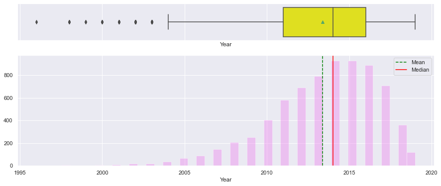

```python
hist_box_plot(carsdf['Year'])
```

Year Observation:

1. Year is Negatively skewed (Mean<Median). Has few outliers on lower side.
2. Used cars sale started increasing after year 2000 and reached it peak around 2015.
3. Used car sales started decreasing after 2015.

Kilometers_Driven Analysis

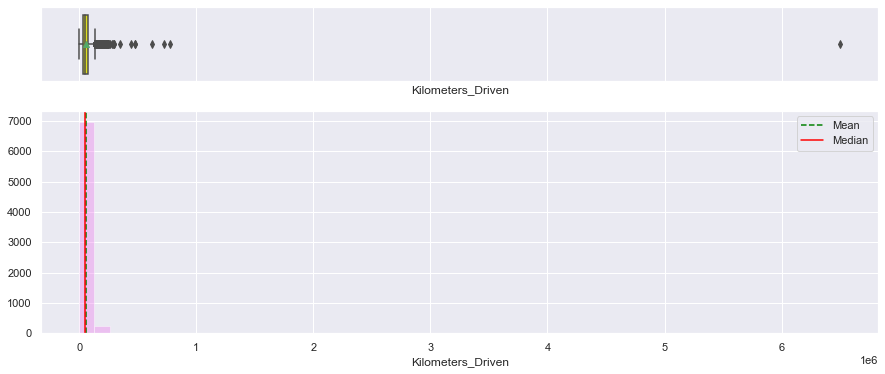

```python
hist_box_plot(carsdf['Kilometers_Driven'])
#hist_box_plot(np.log(carsdf['Kilometers_Driven']))
```

Kilometers_Driven Observation

1. Heavily skewed. Log Transformation should be applied

Mileage Analysis

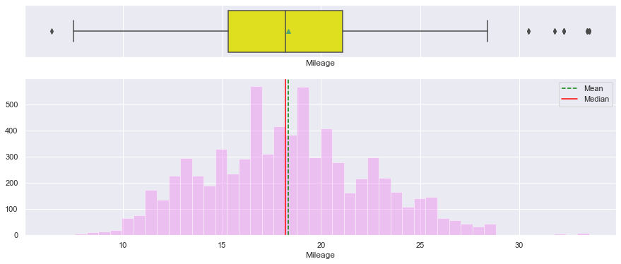

```python
hist_box_plot(carsdf['Mileage'])
```

Engine Analysis

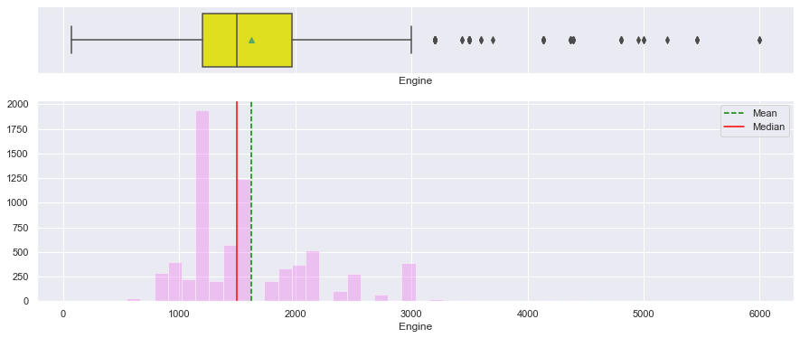

```python
hist_box_plot(carsdf['Engine'])
```

Engine Observation:

1. Median < Mean. Positively skewed
2. Few Outliers observed in data having high Engine units
3. Most cars have Engine between 1000 to 1500 CC

Power Analysis

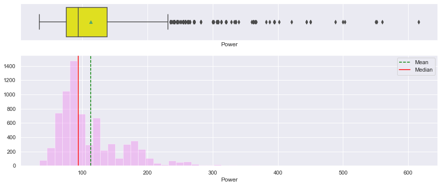

```python
hist_box_plot(carsdf['Power'])
```

Power Observation:¶

1. Median < Mean. Positive skew
2. Few outliers in the data having high values

Seats Analysis

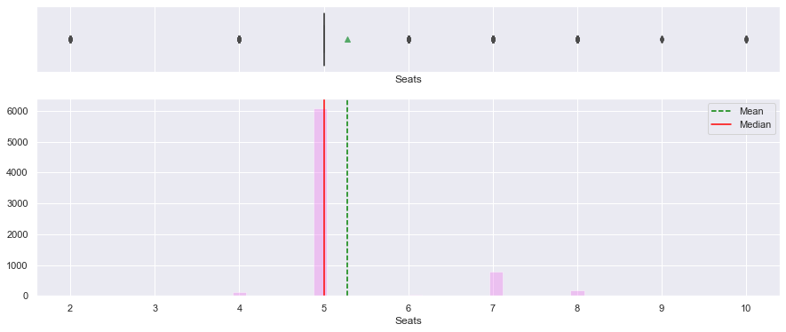

```python
hist_box_plot(carsdf['Seats'])
```

New_Price Analysis

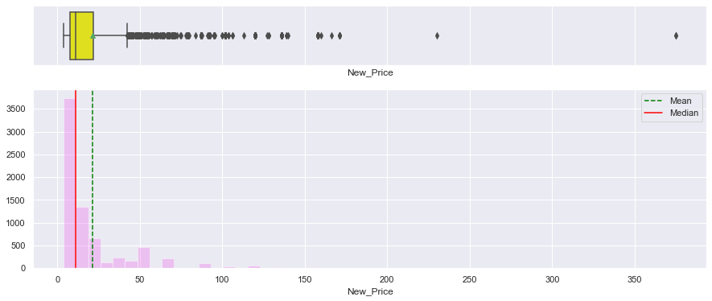

```python
hist_box_plot(carsdf['New_Price'])
```

Price Observation:

```python
#Barplots for categorical variables

def bar_plot(data, z):
    """
    This function will barplot the categorial feature.Adds % at the top
    """
    total = len(data[z])  # length of the column
    plt.figure(figsize=(18, 6))   #Plot size
    plt.xticks(rotation=45)     #Rotate the x axis variables to 45 degree
    plt.title( z + ' Plot',fontweight='bold')    #title of the plot
    #plot countplot.
    ax = sns.countplot(
            data[z],
            palette="Spectral",
            order=data[z].value_counts(ascending=False).index #Sorting the variable count in descending order
    )   #i.e the variable with highest count appears in the left side of plot, followed by others in descending order
    for p in ax.patches:
        percentage = "{:.1f}%".format(100 * p.get_height() / total)  # % of each class of the category
        x = p.get_x() + p.get_width() / 2 - 0.05  # width of the plot
        y = p.get_y() + p.get_height()  # hieght of the plot
        ax.annotate(percentage, (x, y), size=10)  # annotate the percantage
    plt.show()  # show the plot
```

Location Analysis

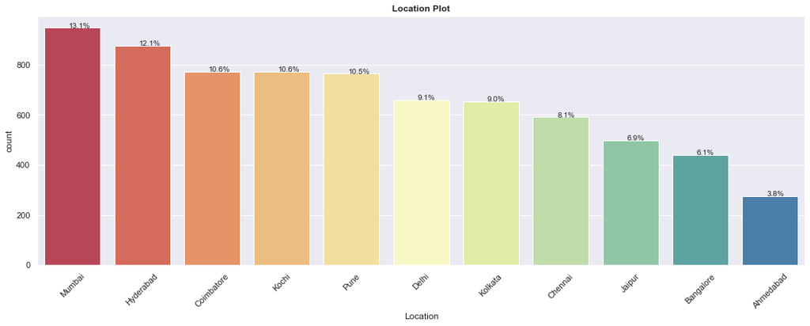

```python
bar_plot(carsdf,"Location")
```

Location Observation:

1. Mumbai has the highest sales in India, followed by Hyderabad.
2. Ahmedabad has the least sales compared to other cities, followed by Bangalore

Fuel_Type Analysis

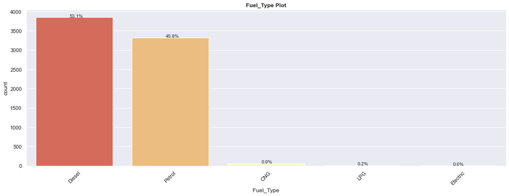

```python
bar_plot(carsdf,"Fuel_Type")
```

Fuel_Type Observation:

1. Dielsel vehicles are the most selling of all followed by Petrol
2. Electric vehicles sales are very minimum. Company should research and find out the reason because Climate change is the hottest topic everyone are discussing. High potention to increase the sales after conducting research and incorporating the outcomes in marketing.

Transmission Analysis

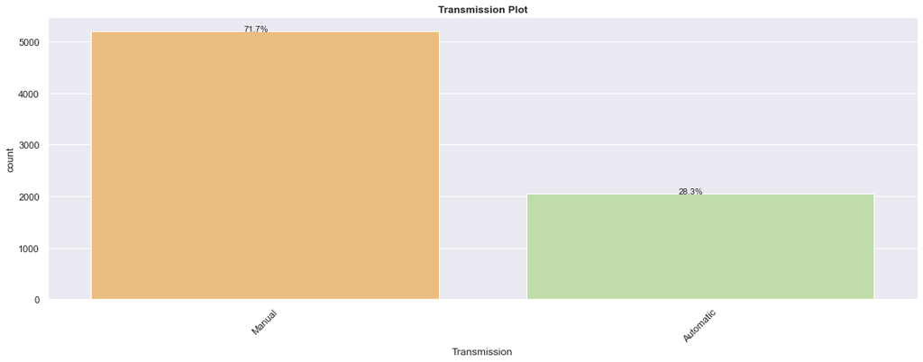

```python
bar_plot(carsdf,"Transmission")
```

Transmission Observation:

Owner_Type Analysis

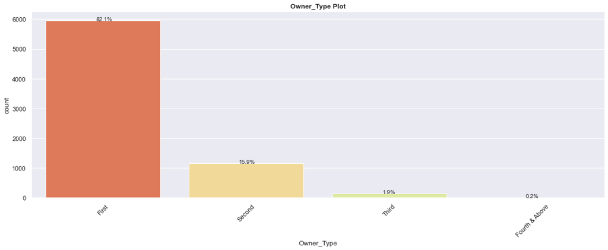

```python
bar_plot(carsdf,"Owner_Type")
```

Owner_Type Observation:

Customers mainly look for Cars with only one owner accounting to 82% of sale

Brand Analysis

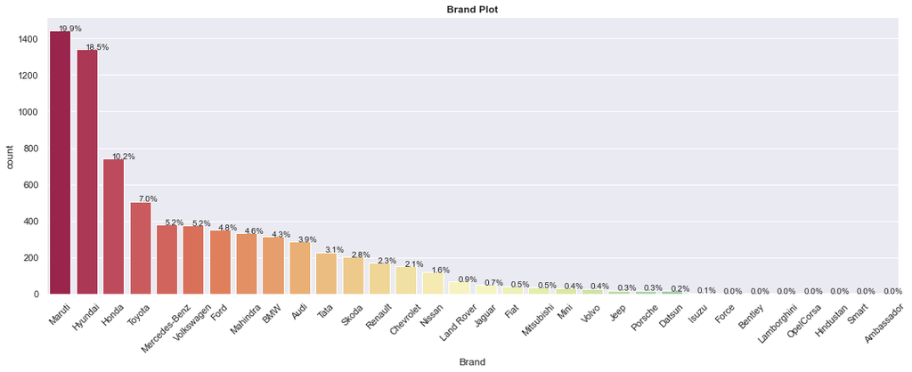

```python
bar_plot(carsdf,"Brand")
```

Brand Observation:

1. Top 5 most selling brands - Maruti, Hyundai, Honda, Toyota, Mercedes Benz
2. Least 5 selling brands - Ambassador, Smart, Hindustan, OpelCorsa, Lamborghini

#### Bivariate Analysis

Understanding correlation between numerical variables based on Pairplot, Correlation Matrix and Heatmap

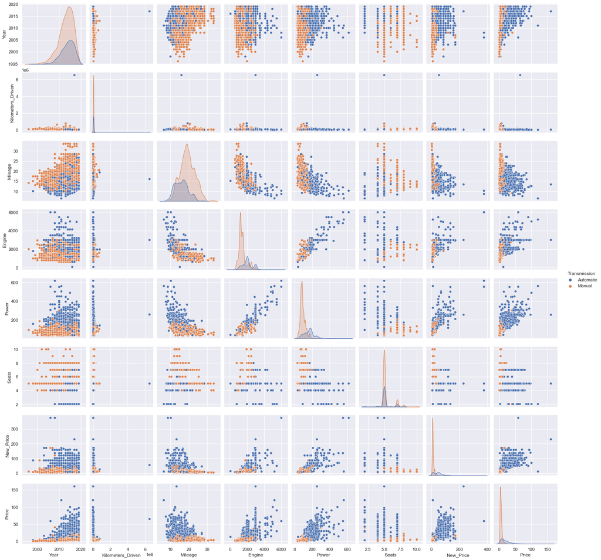

```python
#Generating pairplot to show correlation between numeric variables
sns.pairplot(carsdf, hue='Transmission')
plt.show()
```

|  | Year | Kilometers_Driven | Mileage | Engine | Power | Seats | New_Price | Price |
| --- | --- | --- | --- | --- | --- | --- | --- | --- |
| Year | 1.000000 | -0.187884 | 0.294984 | -0.052730 | 0.024267 | 0.010474 | -0.006323 | 0.305327 |
| Kilometers_Driven | -0.187884 | 1.000000 | -0.069669 | 0.094480 | 0.028595 | 0.090769 | 0.015497 | -0.011493 |
| Mileage | 0.294984 | -0.069669 | 1.000000 | -0.641411 | -0.541821 | -0.347405 | -0.440351 | -0.336361 |
| Engine | -0.052730 | 0.094480 | -0.641411 | 1.000000 | 0.857390 | 0.401945 | 0.695735 | 0.658644 |
| Power | 0.024267 | 0.028595 | -0.541821 | 0.857390 | 1.000000 | 0.093424 | 0.803691 | 0.773166 |
| Seats | 0.010474 | 0.090769 | -0.347405 | 0.401945 | 0.093424 | 1.000000 | 0.038215 | 0.053787 |
| New_Price | -0.006323 | 0.015497 | -0.440351 | 0.695735 | 0.803691 | 0.038215 | 1.000000 | 0.763362 |
| Price | 0.305327 | -0.011493 | -0.336361 | 0.658644 | 0.773166 | 0.053787 | 0.763362 | 1.000000 |

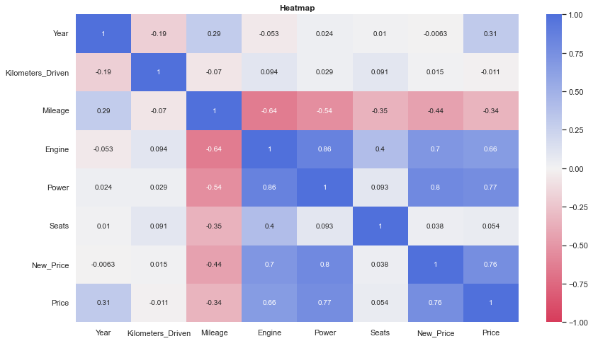

```python
#Check the correlation of numeric variables and generate heatmap

plt.figure(figsize = (14,8))
#create your own palette to show positive values in blue and negative values in red
cmap=sns.diverging_palette(5, 260, as_cmap=True)
#plot heatmap
sns.heatmap(carsdf.corr(), annot=True, cmap=cmap, vmin=-1, vmax=1)
plt.title('Heatmap', fontweight='bold')         #Chart title

#Correlation matrix
carsdf.corr()
```

###### Looking at above Pairplot, Correlation Matrix and Heatmap, we can conclude:

1. High Positive Correlation between

Power - Engine Power - New Price Power - Price Price - New Price High Negative Correlation between

2.Engine - Mileage 2 Power - Mileage

##### Understanding Price relationship with Categorical variables

Price vs Brand Analysis

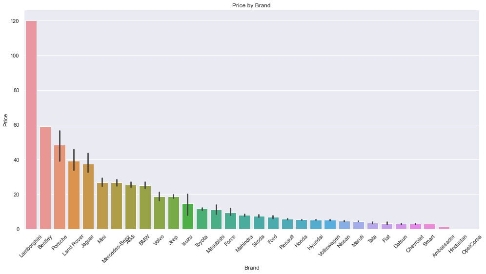

```python
#Average price of cars by brand and sorting in descending order
order=carsdf.groupby(['Brand'])['Price'].mean().fillna(0).sort_values(ascending= False).index
#barplot
sns.catplot(x="Brand", y="Price", data=carsdf, kind='bar', height=7, aspect=2, order=order).set(title='Price by Brand')
plt.xticks(rotation=45);
```

Price vs Brand Observation

1. Most expensive car is Lamborghini followed by Bentley, Porsche, Land Rover, Jaguar
2. Least expensive car is Opelcorsa followed by Hindustan ,Ambassador,Smart, Chevrolet

Price vs Location Analysis

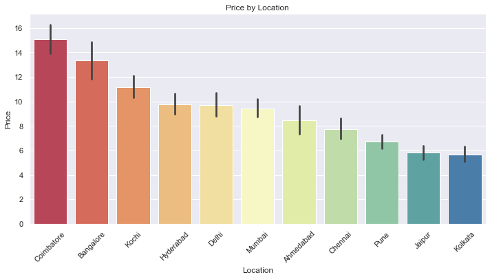

```python
#Average price of cars by Location and sorting in descending order
order=carsdf.groupby(['Location'])['Price'].mean().fillna(0).sort_values(ascending= False).index

sns.catplot(x="Location", y="Price", data=carsdf, kind='bar', height=5, aspect=2, order=order, palette='Spectral').set(title='Price by Location')
plt.xticks(rotation=45);
```

Price vs Location

1.Used Cars are costly in Coimbatore, Bangalore , Kochi.

2.Used Cars are cheapest in Kolkata, Jaipur, Pune.

Price vs Transmission Analysis

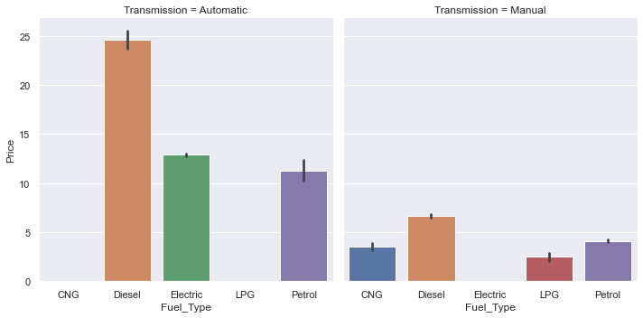

```python
sns.catplot(x="Fuel_Type",y="Price",col="Transmission",data=carsdf,kind='bar')
plt.show()
```

Price vs Transmission Observation:

1. Diesel cars are the costlier cars.
2. Electric cars are costlier in Automatic Transmission compared to Manual Transmission.

Price vs Owner_Type Analysis

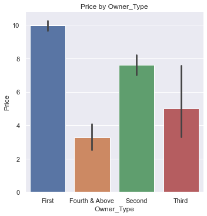

```python
sns.catplot(x="Owner_Type",y="Price",data=carsdf,kind="bar").set(title='Price by Owner_Type')
plt.show()
```

Price vs Owner_Type Observation:

Cars having only one owner is the costliest

###### Understanding Price relationship with other Numerical variables

Price vs Mileage Analysis

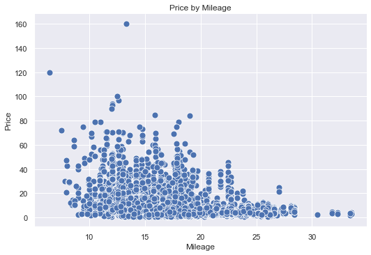

```python
sns.relplot(x='Mileage',
            y='Price',
            data=carsdf,
            s=80,  #Marker Size
            height=5,
            aspect=1.5
            ).set(title='Price by Mileage')
plt.show()
```

Price vs Mileage Observation:

Low Mileage cars have high price

Price vs Engine Analysis

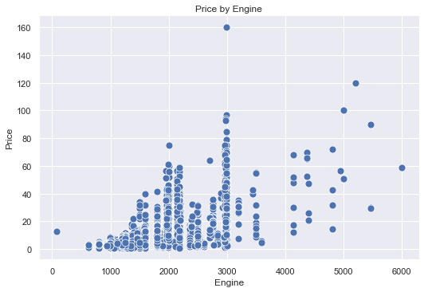

```python
sns.relplot(x='Engine',
            y='Price',
            data=carsdf,
            s=80,  #Marker Size
            height=5,
            aspect=1.5
            ).set(title='Price by Engine')
plt.show()
```

Price vs Engine Observation:

Cars with high CC are costly compared to ones having low CC

Price vs Power Analysis

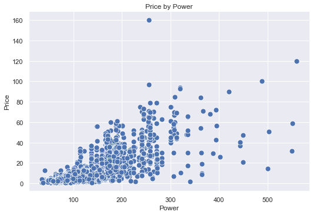

```python
sns.relplot(x='Power',
            y='Price',
            data=carsdf,
            s=80,  #Marker Size
            height=5,
            aspect=1.5
            ).set(title='Price by Power')
plt.show()
```

Price vs Power Observation:

Price of Car increases as Power increases. Inventory has more of low power cars as they sell the most

Price vs Year Analysis

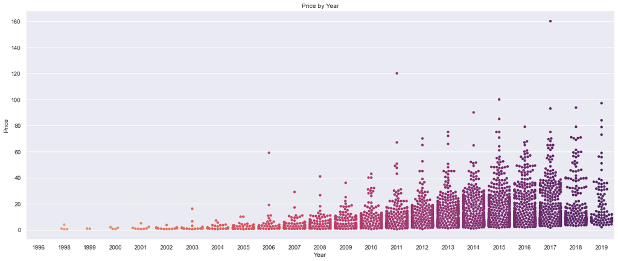

```python
plt.figure(figsize=(20,8))
sns.swarmplot(data=carsdf, x='Year', y='Price',palette='flare').set(title='Price by Year')
plt.show()
```

Price vs Year Observation:

Price of Used cars has increased over years

Price vs Kilometers_Driven Analysis

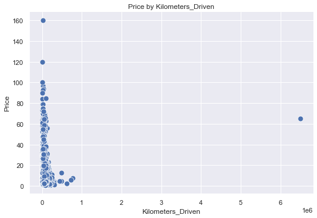

```python
sns.relplot(x='Kilometers_Driven',
            y='Price',
            data=carsdf,
            s=80,  #Marker Size
            height=5,
            aspect=1.5
            ).set(title='Price by Kilometers_Driven')
plt.show()
```

Price vs Kilometers_Driven Observation

Cars having low Kilometers driven are costly

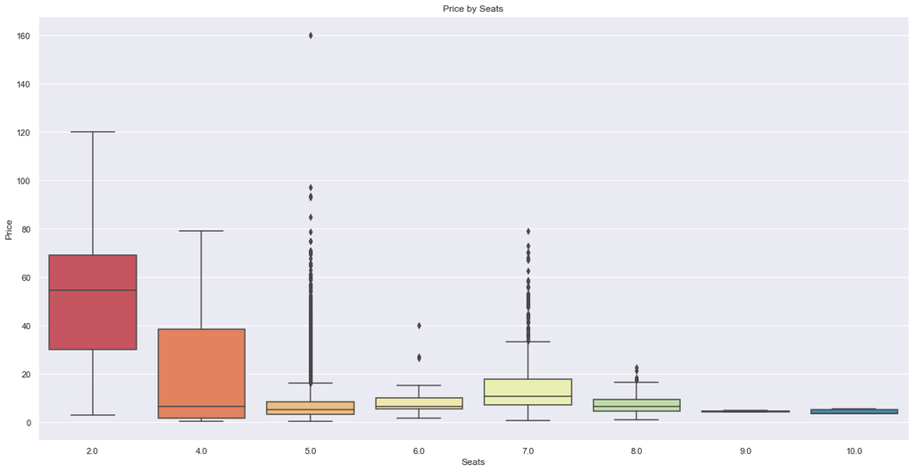

```python
plt.figure(figsize=(20,10))
sns.boxplot(data=carsdf, x='Seats', y='Price',palette='Spectral').set(title='Price by Seats')
plt.show()
```

Price vs Seats Observation:

1. 2 Seater cars are costly
2. 5 Seater cars have varing prices
3. 9 and 10 Seater cars are of less price

Car Brand vs Locations sales

```python
#Brand vs Location sales
pd.crosstab(index=carsdf.Brand, columns=carsdf.Location.sort_values(ascending=True), margins=True, margins_name='Total')
```

| Location Brand | Ahmedabad | Bangalore | Chennai | Coimbatore | Delhi | Hyderabad | Jaipur | Kochi | Kolkata | Mumbai | Pune | Total |
| --- | --- | --- | --- | --- | --- | --- | --- | --- | --- | --- | --- | --- |
| Ambassador | 0 | 0 | 1 | 0 | 0 | 0 | 0 | 0 | 0 | 0 | 0 | 1 |
| Audi | 13 | 40 | 11 | 56 | 31 | 38 | 7 | 33 | 17 | 30 | 9 | 285 |
| BMW | 18 | 30 | 29 | 41 | 24 | 37 | 7 | 33 | 14 | 53 | 26 | 312 |
| Bentley | 0 | 1 | 0 | 0 | 0 | 1 | 0 | 0 | 0 | 0 | 0 | 2 |
| Chevrolet | 3 | 9 | 17 | 16 | 3 | 12 | 12 | 18 | 19 | 16 | 26 | 151 |
| Datsun | 0 | 2 | 2 | 1 | 0 | 1 | 1 | 2 | 4 | 2 | 2 | 17 |
| Fiat | 0 | 0 | 2 | 4 | 1 | 2 | 6 | 3 | 8 | 5 | 7 | 38 |
| Force | 0 | 0 | 1 | 0 | 0 | 0 | 0 | 0 | 2 | 0 | 0 | 3 |
| Ford | 6 | 19 | 55 | 36 | 20 | 61 | 23 | 34 | 28 | 42 | 27 | 351 |
| Hindustan | 0 | 0 | 0 | 0 | 0 | 0 | 0 | 0 | 0 | 0 | 1 | 1 |
| Honda | 34 | 33 | 42 | 57 | 78 | 66 | 46 | 96 | 85 | 126 | 79 | 742 |
| Hyundai | 59 | 100 | 94 | 160 | 104 | 133 | 106 | 159 | 148 | 144 | 133 | 1340 |
| Isuzu | 0 | 0 | 0 | 1 | 0 | 0 | 3 | 0 | 1 | 0 | 0 | 5 |
| Jaguar | 0 | 3 | 1 | 9 | 5 | 9 | 0 | 8 | 5 | 5 | 3 | 48 |
| Jeep | 0 | 0 | 0 | 4 | 1 | 1 | 2 | 3 | 3 | 4 | 1 | 19 |
| Lamborghini | 0 | 0 | 0 | 0 | 1 | 0 | 0 | 0 | 0 | 0 | 0 | 1 |
| Mahindra | 11 | 21 | 33 | 47 | 39 | 36 | 21 | 39 | 26 | 37 | 21 | 331 |
| Maruti | 60 | 42 | 116 | 116 | 139 | 201 | 138 | 146 | 141 | 163 | 182 | 1444 |
| Mercedes-Benz | 8 | 43 | 26 | 59 | 42 | 36 | 12 | 43 | 16 | 64 | 31 | 380 |
| Mini | 1 | 2 | 1 | 2 | 1 | 4 | 1 | 6 | 1 | 9 | 3 | 31 |
| Mitsubishi | 1 | 5 | 6 | 5 | 4 | 4 | 1 | 2 | 1 | 4 | 3 | 36 |
| Nissan | 2 | 1 | 15 | 9 | 5 | 16 | 11 | 11 | 16 | 19 | 12 | 117 |
| OpelCorsa | 0 | 0 | 0 | 0 | 0 | 1 | 0 | 0 | 0 | 0 | 0 | 1 |
| Porsche | 0 | 2 | 0 | 3 | 2 | 2 | 0 | 4 | 2 | 4 | 0 | 19 |
| Renault | 5 | 15 | 8 | 15 | 15 | 17 | 23 | 23 | 7 | 23 | 19 | 170 |
| Skoda | 7 | 11 | 6 | 14 | 22 | 30 | 12 | 17 | 12 | 46 | 25 | 202 |
| Smart | 0 | 0 | 0 | 0 | 0 | 0 | 0 | 0 | 0 | 0 | 1 | 1 |
| Tata | 10 | 10 | 26 | 25 | 8 | 34 | 25 | 12 | 20 | 15 | 43 | 228 |
| Toyota | 20 | 26 | 52 | 44 | 78 | 70 | 19 | 37 | 33 | 67 | 61 | 507 |
| Volkswagen | 12 | 17 | 43 | 35 | 21 | 45 | 22 | 28 | 45 | 62 | 44 | 374 |
| Volvo | 3 | 3 | 3 | 2 | 3 | 7 | 0 | 4 | 0 | 1 | 2 | 28 |
| Land Rover | 2 | 5 | 1 | 11 | 13 | 12 | 1 | 11 | 0 | 7 | 4 | 67 |
| Total | 275 | 440 | 591 | 772 | 660 | 876 | 499 | 772 | 654 | 948 | 765 | 7252 |

Above table shows the car sales across different locations

[figure not shown]

```python
sns.catplot(data=carsdf,
              y="Brand",
              kind='count',
              height=8,
              aspect=3 ,
              row="Location",
              palette="flare",
              order = carsdf["Brand"].value_counts(ascending=False).index
           )
plt.show()
```

##### Brand vs Location Observation

```python
Most selling brands across various locations:

Ahmedabad: Maruti
Bangalore: Hyundai
Chennai: Maruti
Coimbatore: Hyundai
Delhi: Maruti
Hyderabad: Maruti
Jaipur: Maruti
Kochi: Hyundai
Kolkata: Hyundai
Mumbai: Maruti
Pune: Maruti
```

## Multivariate Analysis

[output not shown]

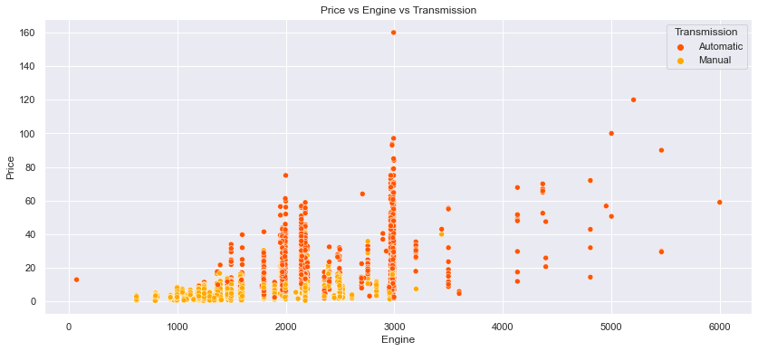

```python
plt.figure(figsize=(14,6))
plt.title("Price vs Engine vs Transmission")
sns.scatterplot(x='Engine', y='Price', hue='Transmission', data=carsdf, palette='autumn')
plt.show()
```

Automatic cars'Engine capacity is more than Manual cars and tend to be pricey

Price vs Power vs Transmission:

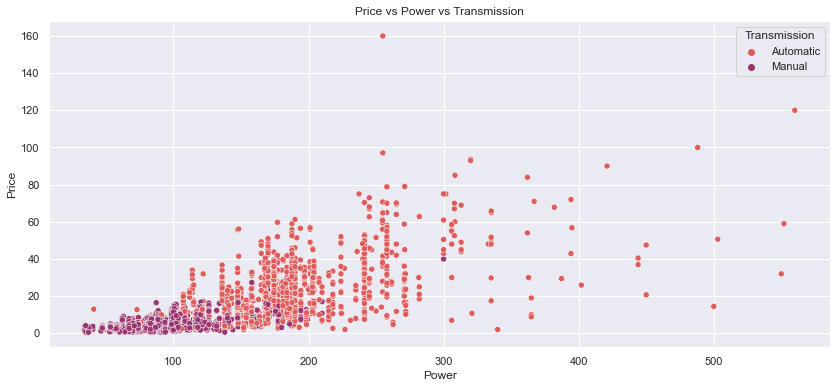

```python
plt.figure(figsize=(14,6))
plt.title("Price vs Power vs Transmission")
sns.scatterplot(x='Power', y='Price', hue='Transmission', data=carsdf, palette='flare')
plt.show()
```

Automatic cars have more power compared to manual cars and tend to be more costly

###### Price Vs Mileage Vs Transmission

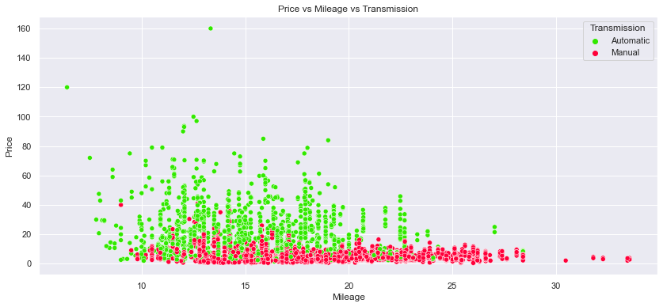

```python
plt.figure(figsize=(14,6))
plt.title("Price vs Mileage vs Transmission")
sns.scatterplot(x='Mileage', y='Price', hue='Transmission', data=carsdf, palette='prism')
plt.show()
```

Price vs Year vs Transmission

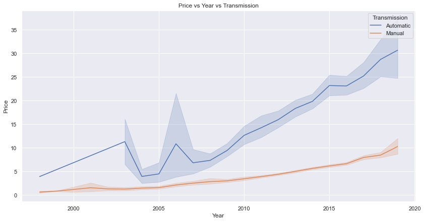

```python
plt.figure(figsize=(14,7))
plt.title("Price vs Year vs Transmission")
sns.lineplot(x='Year', y='Price',hue='Transmission',data=carsdf)
plt.show()
```

Price of Automatic cars have increased over years compared to Manual cars

### Insights Based on EDA:

###### Dataset Statistics:

#### Dataset has 7253 rows and 14 columns

1. 5 numeric variables and 9 categorical/object variables
2. Missing cell % ~ 8%
3. Year variable is negatively skewed
4. Mileage is uniformly distributed
5. Kilometers_Driven, Price and New_Price are heavily skewed. Outliers present
6. High Positive Correlation between

Power - Engine Power - New Price Power - Price Price - New Price

High Negative Correlation between Engine - Mileage Power - Mileage

Car Profile:

Ahmedabad: Maruti Bangalore: Hyundai Chennai: Maruti Coimbatore: Hyundai Delhi: Maruti Hyderabad: Maruti Jaipur: Maruti Kochi: Hyundai Kolkata: Hyundai Mumbai: Maruti Pune: Maruti

1. Used car sales started picking up after 2000, reached peak in 2015 and started decreasing later on.
2. Used cars are costly in Coimbatore, Bangalore and Kochi. Cheap in Kolkata, Jaipur and Pune
3. Most customers prefer to buy 5 Seater cars and only one owner.
4. 2 Seater cars are costly.5 Seater cars price vary significantly.
5. Diesel vehicles are most popular. Electric vehicles are least popular.
6. Diesel cars are the costliest cars. Electric cars are costlier in auto transmission.
7. Cars with engine 1000-1500 CC, mileage of 15-20, Power less than 100bhp sell the most
8. Price of Car increases as Power increases. Inventory has more of low power cars as they sell the most.

We have completed analysis of all the variables and relations

###### Variable Transformation

```python
#Dropping NANs rows
print('Shape of file before dropping Nans :',carsdf.shape)
carsdf.dropna(inplace=True,axis=0)
print('Shape of file after dropping Nans :',carsdf.shape)
```

```
Shape of file before dropping Nans : (7252, 14)
Shape of file after dropping Nans : (6019, 14)
```

Based on EDA, we have seen data having skewness and outliers. We have to apply log transformation and may need to treat outliers before model generation Kilometers_Driven, New_Price and Price are heavily skewed. Log Transformation may be good fit.

```python
pd.set_option("display.max_rows", 200) #resetting it back to 200 rows
#Checking to see if there are zeros or negative values
print('Kilometers_Driven with values <=0 : ',carsdf[carsdf['Kilometers_Driven']<=0.0].count().sum())
print('New_Price with values <=0 : ',carsdf[carsdf['New_Price']<=0.0].count().sum())
print('Price with values <=0 : ',carsdf[carsdf['Price']<=0.0].count().sum())
```

```
Kilometers_Driven with values <=0 :  0
New_Price with values <=0 :  0
Price with values <=0 :  0
```

###### Outlier detection using IQR

Outliers in the data can distort predictions. The challenge is to know whether the data is truly an outlier or an interesting finding which should be kept.Lets compute IQR (interval from 1st quartile to the 3rd quartile) and flag entries outside 1.5*IQR as outliers. The values are displayed in %

```python
def frac_outside_1pt5_IQR(x):
    length = 1.5 * np.diff(np.quantile(x, [.25, .75]))
    return np.mean(np.abs(x - np.median(x)) > length[0])

num_cols=['Year','Kilometers_Driven','Mileage','Engine','Power','Seats','New_Price','Price']

for i in num_cols:
    print(i+' variable')
    print('Before log ',frac_outside_1pt5_IQR(carsdf[i])*100)
    print('After log ',frac_outside_1pt5_IQR(np.log(carsdf[i]))*100,'\n')
```

```
Year variable
Before log  3.5886359860441934
After log  3.5886359860441934

Kilometers_Driven variable
Before log  6.296727031068283
After log  8.80544941020103

Mileage variable
Before log  2.4754942681508556
After log  3.2397408207343417

Engine variable
Before log  7.775377969762419
After log  1.4454228277122445

Power variable
Before log  8.290413689981726
After log  4.950988536301711

Seats variable
Before log  15.982721382289416
After log  15.982721382289416

New_Price variable
Before log  20.667885030736002
After log  11.01511879049676

Price variable
Before log  16.265160325635488
After log  9.237414852965609
```

```python
#Function to calculate and display outlier values

def outlier_values(df,col):
    '''
    Calculate and display outlier values which are > 4*IQR
    '''
    print('Determining outlier values for: ',col)
    quartiles = np.quantile(df[col][df[col].notnull()], [.25, .75])
    col_4iqr = 4 * (quartiles[1] - quartiles[0])
    print(f'\nQ1 = {quartiles[0]}, Q3 = {quartiles[1]}, 4*IQR = {col_4iqr}')
    outlier_vals = df.loc[np.abs(df[col] - df[col].median()) > col_4iqr, col]
    print('\nOutlier values:\n',np.sort(outlier_vals.unique()))
    print('---------------------------------------------------------')

cols=['Kilometers_Driven','Mileage','Engine','Power','New_Price','Price']
for i in cols:
    outlier_values(carsdf,i)
```

```
Determining outlier values for:  Kilometers_Driven

Q1 = 34000.0, Q3 = 73000.0, 4*IQR = 156000.0

Outlier values:
 [ 210000  215000  215750  216000  220000  225000  227000  230000  231673
  232000  234000  240000  242000  248000  250000  255000  262000  282000
  299322  300000  445000  480000  620000  720000  775000 6500000]
---------------------------------------------------------
Determining outlier values for:  Mileage

Q1 = 15.29, Q3 = 21.1, 4*IQR = 23.24000000000001

Outlier values:
 []
---------------------------------------------------------
Determining outlier values for:  Engine

Q1 = 1197.0, Q3 = 1984.0, 4*IQR = 3148.0

Outlier values:
 [4806. 4951. 5000. 5204. 5461. 5998.]
---------------------------------------------------------
Determining outlier values for:  Power

Q1 = 75.0, Q3 = 138.1, 4*IQR = 252.39999999999998

Outlier values:
 [362.07 362.9  364.9  367.   382.   387.3  394.3  395.   402.   421.
 444.   450.   488.1  500.   503.   550.   552.   560.  ]
---------------------------------------------------------
Determining outlier values for:  New_Price

Q1 = 7.88, Q3 = 21.77, 4*IQR = 55.56

Outlier values:
 [ 67.1    67.67   67.87   69.22   69.37   69.47   69.59   69.675  70.43
  70.55   71.15   71.82   72.64   74.49   75.12   78.31   78.76   79.43
  79.78   83.92   86.97   87.57   91.23   91.38   92.5    92.79   95.04
  95.13   95.38   99.92  100.    101.96  102.    104.    106.    113.
```

[output cut: 15 more lines]

```
  38.95  38.99  39.    39.05  39.22  39.41  39.45  39.47  39.5   39.51
  39.58  39.62  39.75  39.84  40.    40.47  40.5   40.66  40.88  41.
  41.5   41.6   41.75  42.    42.5   42.75  42.83  42.91  43.    43.3
  43.35  43.6   43.74  43.78  44.    44.5   44.56  44.76  44.83  45.
  45.52  45.61  45.62  45.64  45.73  45.77  45.82  45.86  46.    46.95
  47.35  47.5   47.7   48.    48.22  48.5   48.63  48.76  48.91  49.
  49.22  49.24  49.79  50.    50.22  50.29  50.5   50.66  50.97  51.
  51.35  51.43  51.52  51.69  52.    52.5   52.54  53.11  53.83  54.
  54.45  55.    55.54  55.7   55.76  56.    56.14  56.5   56.73  56.8
  57.    58.    58.54  58.73  58.91  59.    59.29  59.65  59.72  60.
  60.75  60.95  61.25  61.29  62.67  62.81  64.    64.75  64.87  64.95
  65.    65.81  67.    67.83  68.    68.94  69.5   70.    70.15  70.36
  70.66  70.8   70.99  72.    72.94  75.    78.8   79.    83.96  85.
  90.    93.    93.67  97.07 100.   120.   160.  ]
---------------------------------------------------------
```

1. New_Price had lot of Nulls and we imputed with median values.
2. Moreover, the data looks continuous and hence not looking into values
3. Price is dependent variable and need to take a look at value which is >90
4. Engine, Power and Kilometers_Driven should be checked

```python
#checking Engine & Power values

eng = [4806.0,4951.0,5000.0,5461.0,5998.0]
powr = [362.07,362.9,364.9,367.0,382.0,387.3,394.3,395.0,402.0,421.0,
        444.0,450.0,488.1,500.0,503.0,550.0,552.0]
for x in eng:
    display(carsdf[carsdf['Engine']==x][['Brand','Model','Engine']])

for y in powr:
    display(carsdf[carsdf['Power']==y][['Brand','Model','Power']])
```

|  | Brand | Model | Engine |
| --- | --- | --- | --- |
| 70 | Porsche | Cayenne 2009-2014 Turbo | 4806.0 |
| 2100 | Porsche | Cayenne Turbo S | 4806.0 |
| 2978 | Porsche | Panamera 2010 2013 4S | 4806.0 |
| 5603 | Porsche | Panamera 2010 2013 Diesel | 4806.0 |

|  | Brand | Model | Engine |
| --- | --- | --- | --- |
| 4451 | Ford | Mustang V8 | 4951.0 |

|  | Brand | Model | Engine |
| --- | --- | --- | --- |
| 5088 | Jaguar | XJ 5.0 L V8 Supercharged | 5000.0 |
| 5919 | Jaguar | F Type 5.0 V8 S | 5000.0 |

|  | Brand | Model | Engine |
| --- | --- | --- | --- |
| 152 | Mercedes-Benz | S Class 2005 2013 S 500 | 5461.0 |
| 4691 | Mercedes-Benz | SLK-Class 55 AMG | 5461.0 |
| 4722 | Mercedes-Benz | SL-Class SL 500 | 5461.0 |

|  | Brand | Model | Engine |
| --- | --- | --- | --- |
| 5521 | Bentley | Continental Flying Spur | 5998.0 |

|  | Brand | Model | Power |
| --- | --- | --- | --- |
| 134 | Mercedes-Benz | SLC 43 AMG | 362.07 |
| 2095 | Mercedes-Benz | SLC 43 AMG | 362.07 |

|  | Brand | Model | Power |
| --- | --- | --- | --- |
| 152 | Mercedes-Benz | S Class 2005 2013 S 500 | 362.9 |

|  | Brand | Model | Power |
| --- | --- | --- | --- |
| 589 | Mercedes-Benz | S Class 2005 2013 S 350 L | 364.9 |
| 1930 | Mercedes-Benz | S Class 2005 2013 S 350 L | 364.9 |
| 4342 | Mercedes-Benz | S Class 2005 2013 S 350 L | 364.9 |

|  | Brand | Model | Power |
| --- | --- | --- | --- |
| 418 | Mercedes-Benz | GLC 43 AMG Coupe | 367.0 |

|  | Brand | Model | Power |
| --- | --- | --- | --- |
| 5341 | Porsche | Cayenne S Diesel | 382.0 |

|  | Brand | Model | Power |
| --- | --- | --- | --- |
| 4722 | Mercedes-Benz | SL-Class SL 500 | 387.3 |

|  | Brand | Model | Power |
| --- | --- | --- | --- |
| 2978 | Porsche | Panamera 2010 2013 4S | 394.3 |
| 5603 | Porsche | Panamera 2010 2013 Diesel | 394.3 |

|  | Brand | Model | Power |
| --- | --- | --- | --- |
| 4451 | Ford | Mustang V8 | 395.0 |

|  | Brand | Model | Power |
| --- | --- | --- | --- |
| 3341 | BMW | 7 Series 2007-2012 750Li | 402.0 |

|  | Brand | Model | Power |
| --- | --- | --- | --- |
| 4691 | Mercedes-Benz | SLK-Class 55 AMG | 421.0 |

|  | Brand | Model | Power |
| --- | --- | --- | --- |
| 148 | Audi | RS5 Coupe | 444.0 |
| 4061 | Audi | RS5 Coupe | 444.0 |

|  | Brand | Model | Power |
| --- | --- | --- | --- |
| 4627 | BMW | 6 Series 650i Coupe | 450.0 |
| 4821 | BMW | 6 Series 630i Coupe | 450.0 |

|  | Brand | Model | Power |
| --- | --- | --- | --- |
| 5919 | Jaguar | F Type 5.0 V8 S | 488.1 |

|  | Brand | Model | Power |
| --- | --- | --- | --- |
| 70 | Porsche | Cayenne 2009-2014 Turbo | 500.0 |

|  | Brand | Model | Power |
| --- | --- | --- | --- |
| 5088 | Jaguar | XJ 5.0 L V8 Supercharged | 503.0 |

|  | Brand | Model | Power |
| --- | --- | --- | --- |
| 2100 | Porsche | Cayenne Turbo S | 550.0 |

|  | Brand | Model | Power |
| --- | --- | --- | --- |
| 5521 | Bentley | Continental Flying Spur | 552.0 |

All of them are luxury cars and they usually have high power. Not considering any of Engine & Power values as outlier

```python
#Checking Kilometers_Driven

km=[250000,255000,262000,282000,299322,300000,445000,480000,620000,720000,775000,6500000]

for j in km:
    display(carsdf[carsdf['Kilometers_Driven']==j][['Year','Kilometers_Driven','Engine','Owner_Type','New_Price','Price','Brand','Model']])
```

|  | Year | Kilometers_Driven | Engine | Owner_Type | New_Price | Price | Brand | Model |
| --- | --- | --- | --- | --- | --- | --- | --- | --- |
| 3894 | 2010 | 250000 | 2494.0 | Second | 24.01 | 6.5 | Toyota | Innova 2.5 GX 7 STR |
| 4719 | 2014 | 250000 | 2494.0 | First | 24.01 | 10.9 | Toyota | Innova 2.5 GX (Diesel) 8 Seater |
| 5834 | 2013 | 250000 | 2494.0 | Second | 24.01 | 7.9 | Toyota | Innova 2.5 G (Diesel) 8 Seater |

|  | Year | Kilometers_Driven | Engine | Owner_Type | New_Price | Price | Brand | Model |
| --- | --- | --- | --- | --- | --- | --- | --- | --- |
| 1846 | 2013 | 255000 | 2494.0 | Third | 24.01 | 6.5 | Toyota | Innova 2.5 GX (Diesel) 7 Seater |

|  | Year | Kilometers_Driven | Engine | Owner_Type | New_Price | Price | Brand | Model |
| --- | --- | --- | --- | --- | --- | --- | --- | --- |
| 29 | 2007 | 262000 | 2494.0 | Fourth & Above | 24.01 | 4.0 | Toyota | Innova 2.5 V Diesel 7-seater |

|  | Year | Kilometers_Driven | Engine | Owner_Type | New_Price | Price | Brand | Model |
| --- | --- | --- | --- | --- | --- | --- | --- | --- |
| 1975 | 2012 | 282000 | 1798.0 | First | 33.36 | 3.3 | Skoda | Superb 1.8 TSI MT |

|  | Year | Kilometers_Driven | Engine | Owner_Type | New_Price | Price | Brand | Model |
| --- | --- | --- | --- | --- | --- | --- | --- | --- |
| 1528 | 2005 | 299322 | 2494.0 | First | 24.01 | 4.0 | Toyota | Innova 2.5 G (Diesel) 8 Seater BS IV |

|  | Year | Kilometers_Driven | Engine | Owner_Type | New_Price | Price | Brand | Model |
| --- | --- | --- | --- | --- | --- | --- | --- | --- |
| 3649 | 2008 | 300000 | 1405.0 | First | 7.63 | 1.0 | Tata | Indigo LS |

|  | Year | Kilometers_Driven | Engine | Owner_Type | New_Price | Price | Brand | Model |
| --- | --- | --- | --- | --- | --- | --- | --- | --- |
| 4491 | 2013 | 445000 | 1197.0 | First | 10.25 | 4.45 | Hyundai | i20 Magna Optional 1.2 |

|  | Year | Kilometers_Driven | Engine | Owner_Type | New_Price | Price | Brand | Model |
| --- | --- | --- | --- | --- | --- | --- | --- | --- |
| 2823 | 2015 | 480000 | 1968.0 | First | 10.15 | 13.0 | Volkswagen | Jetta 2013-2015 2.0L TDI Highline AT |
| 3092 | 2015 | 480000 | 1497.0 | First | 13.58 | 5.0 | Honda | City i VTEC SV |

|  | Year | Kilometers_Driven | Engine | Owner_Type | New_Price | Price | Brand | Model |
| --- | --- | --- | --- | --- | --- | --- | --- | --- |
| 358 | 2009 | 620000 | 1197.0 | First | 10.25 | 2.7 | Hyundai | i10 Magna 1.2 |

|  | Year | Kilometers_Driven | Engine | Owner_Type | New_Price | Price | Brand | Model |
| --- | --- | --- | --- | --- | --- | --- | --- | --- |
| 1860 | 2013 | 720000 | 1598.0 | First | 13.23 | 5.9 | Volkswagen | Vento Diesel Highline |

|  | Year | Kilometers_Driven | Engine | Owner_Type | New_Price | Price | Brand | Model |
| --- | --- | --- | --- | --- | --- | --- | --- | --- |
| 340 | 2013 | 775000 | 1968.0 | First | 25.83 | 7.5 | Skoda | Octavia Ambition Plus 2.0 TDI AT |

|  | Year | Kilometers_Driven | Engine | Owner_Type | New_Price | Price | Brand | Model |
| --- | --- | --- | --- | --- | --- | --- | --- | --- |
| 2328 | 2017 | 6500000 | 2993.0 | First | 55.07 | 65.0 | BMW | X5 xDrive 30d M Sport |

```python
#Creating _BKP variable. Applying transformation on that and copying it back to original variable

#KMs to be updated
km=[210000,  215000,  215750,  216000  ,220000,  225000 , 227000,  230000 , 231673,
  234000,  240000,  242000,  248000 , 250000,  255000 , 262000,  282000,  299322,
  300000,  445000,  480000,  620000,  720000 , 775000, 6500000]

#copy variable to _bkp
carsdf['Kilometers_Driven_bkp'] = carsdf['Kilometers_Driven']

#replace the values with np.nan
for j in km:
    carsdf.loc[carsdf['Kilometers_Driven_bkp']==j, 'Kilometers_Driven_bkp']=np.nan

print('Number of nulls in Kilometers_Driven_bkp: ',carsdf['Kilometers_Driven_bkp'].isnull().sum())

#Take the median of cars grouped by Brand & Model and update
carsdf['Kilometers_Driven_bkp'] = carsdf.groupby(['Brand','Model'])['Kilometers_Driven_bkp'].apply(lambda val:val.fillna(val.median()))

#checking if any more nan's in data
print('Nulls in Kilometers_Driven_bkp after imputation with Median(Brand+Model): ',carsdf['Kilometers_Driven_bkp'].isnull().sum())

#if nan's still exist, then update median() based on brand
carsdf['Kilometers_Driven_bkp'] = carsdf.groupby(['Brand'])['Kilometers_Driven_bkp'].apply(lambda val:val.fillna(val.median()))

#checking if any more nans
print('Nulls in Kilometers_Driven_bkp after imputation with Median(Brand):',carsdf['Kilometers_Driven_bkp'].isnull().sum())

print('copying Kilometers_Driven_bkp to Kilometers_Driven')

#copy data from _bkp to original variable
carsdf['Kilometers_Driven'] = carsdf['Kilometers_Driven_bkp']
print('dropping Kilometers_Driven_bkp ')
#dropping _bkp
carsdf.drop(['Kilometers_Driven_bkp'],axis=1,inplace=True)
```

```
Number of nulls in Kilometers_Driven_bkp:  28
Nulls in Kilometers_Driven_bkp after imputation with Median(Brand+Model):  6
Nulls in Kilometers_Driven_bkp after imputation with Median(Brand): 0
copying Kilometers_Driven_bkp to Kilometers_Driven
dropping Kilometers_Driven_bkp
```

```python
#Checking Prices of Cars > 90 Lakhs
carsdf[carsdf['Price']>90]
```

|  | Location | Year | Kilometers_Driven | Fuel_Type | Transmission | Owner_Type | Mileage | Engine | Power | Seats | New_Price | Price | Brand | Model |
| --- | --- | --- | --- | --- | --- | --- | --- | --- | --- | --- | --- | --- | --- | --- |
| 1505 | Kochi | 2019 | 26013.0 | Diesel | Automatic | First | 12.65 | 2993.0 | 255.0 | 5.0 | 139.000 | 97.07 | Land Rover | Rover Range Rover Sport SE |
| 1974 | Coimbatore | 2018 | 28060.0 | Petrol | Automatic | First | 12.05 | 2979.0 | 320.0 | 5.0 | 158.000 | 93.67 | BMW | 7 Series 740Li |
| 1984 | Bangalore | 2017 | 17465.0 | Petrol | Automatic | First | 12.05 | 2979.0 | 320.0 | 5.0 | 158.000 | 93.00 | BMW | 7 Series 740Li |
| 4079 | Hyderabad | 2017 | 25000.0 | Diesel | Automatic | First | 13.33 | 2993.0 | 255.0 | 5.0 | 230.000 | 160.00 | Land Rover | Rover Range Rover 3.0 Diesel LWB Vogue |
| 5781 | Delhi | 2011 | 6500.0 | Petrol | Automatic | Third | 6.40 | 5204.0 | 560.0 | 2.0 | 11.300 | 120.00 | Lamborghini | Gallardo Coupe |
| 5919 | Hyderabad | 2015 | 8000.0 | Petrol | Automatic | First | 12.50 | 5000.0 | 488.1 | 2.0 | 69.675 | 100.00 | Jaguar | F Type 5.0 V8 S |

Data looks good. All of them are luxury cars. The Price also depends on Supply & Demand. In recent years, used car market has significantly gone up. Dealers may be looking to sell the cars for more profit.It is also subjected to inflation in market. During current pandemic situation, rich customers who want to invest in cars may end up buying such used luxury cars from market rather than new one. Moreover, the Kilometers_Driven for above cars are attractive. Therefore retaining the Price as is and not treating any values as Outlier.

In Univariate analysis, we saw Kilometers_Driven, Price and New Price are heavily skewed. None of the values contain negative or zeros. Hence, log transformation can be applied

###### Log Transformation

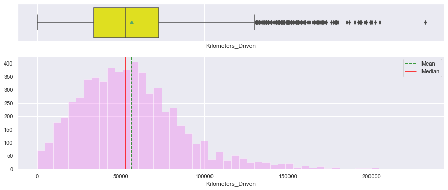

```python
hist_box_plot(carsdf['Kilometers_Driven'])
```

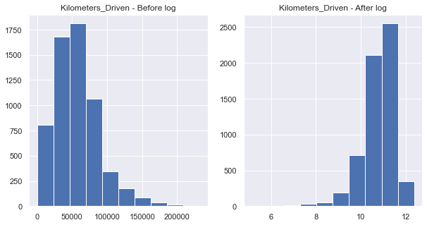

```python
#Log Transformation on Kilometers_Driven
plt.figure(figsize = (10,5))
plt.subplot(1, 2, 1)
plt.title('Kilometers_Driven - Before log')
plt.hist(carsdf['Kilometers_Driven'])

plt.subplot(1, 2, 2)
plt.title('Kilometers_Driven - After log')
plt.hist(np.log(carsdf['Kilometers_Driven']))

plt.show()
```

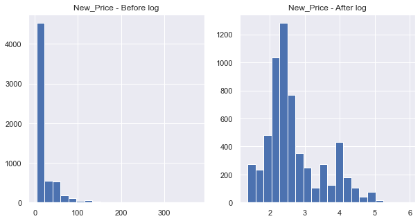

```python
#Log Transformation on New_Price

plt.figure(figsize = (10,5))
plt.subplot(1, 2, 1)
plt.title('New_Price - Before log')
plt.hist(carsdf['New_Price'],20)

plt.subplot(1, 2, 2)
plt.title('New_Price - After log')
plt.hist(np.log(carsdf['New_Price']),20)

plt.show()
```